# R Notebook

```r
library(knitr)
library(ggplot2)
library(plyr)
library(dplyr)
library(corrplot)
library(caret)
library(gridExtra)
library(scales)
library(Rmisc)
library(ggrepel)
library(randomForest)
library(psych)
library(xgboost)
```

```r
train <- read.csv("../../Data/train.csv", stringsAsFactors = F)
test <- read.csv("../../Data/test.csv", stringsAsFactors = F)
```

```r
dim(train)
```

```
[1] 1460   81
```

```r
str(train[,c(1:10, 81)]) #display first 10 variables and the response variable
```

```
'data.frame':   1460 obs. of  11 variables:
 $ Id         : int  1 2 3 4 5 6 7 8 9 10 ...
 $ MSSubClass : int  60 20 60 70 60 50 20 60 50 190 ...
 $ MSZoning   : chr  "RL" "RL" "RL" "RL" ...
 $ LotFrontage: int  65 80 68 60 84 85 75 NA 51 50 ...
 $ LotArea    : int  8450 9600 11250 9550 14260 14115 10084 10382 6120 7420 ...
 $ Street     : chr  "Pave" "Pave" "Pave" "Pave" ...
 $ Alley      : chr  NA NA NA NA ...
 $ LotShape   : chr  "Reg" "Reg" "IR1" "IR1" ...
 $ LandContour: chr  "Lvl" "Lvl" "Lvl" "Lvl" ...
 $ Utilities  : chr  "AllPub" "AllPub" "AllPub" "AllPub" ...
 $ SalePrice  : int  208500 181500 223500 140000 250000 143000 307000 200000 129900 118000 ...
```

```r
#Getting rid of the IDs but keeping the test IDs in a vector. These are needed to compose the submission file
test_labels <- test$Id
test$Id <- NULL
train$Id <- NULL
```

```r
test$SalePrice <- NA
all <- rbind(train, test)
dim(all)
```

```
[1] 2919   80
```

4. Exploring some of the most important variables 4.1 The response variable; SalePrice

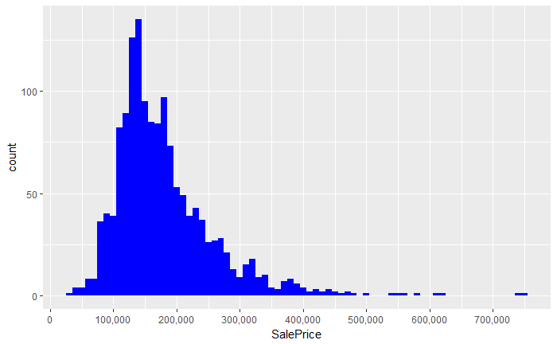

```r
ggplot (data = all[!is.na(all$SalePrice),], aes(x=SalePrice)) +
      geom_histogram(fill="blue", binwidth = 10000) +
      scale_x_continuous(breaks = seq(0, 800000, by = 100000), labels = comma)
```

```r
summary(all$SalePrice)
```

```
   Min. 1st Qu.  Median    Mean 3rd Qu.    Max.    NA's
  34900  129975  163000  180921  214000  755000    1459
```

The sale prices are right skewed. This was expected as few people can afford very expensive houses.

Next, let’s see the most important numeric predictorsby look at the correlation with the SalePrice

4.2 The most important numeric predictors 4.2.1 Correlations with SalePrice

```r
numericVars <- which(sapply(all, is.numeric))
numericVarNames <- names (numericVars)
cat("There are", length(numericVars), "numeric variables")
```

```
There are 37 numeric variables
```

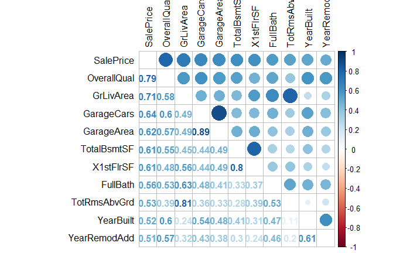

```r
all_numVar <- all[,numericVars]
cor_numVar <- cor(all_numVar, use = "pairwise.complete.obs") #correlation of all numeric variables
#sort on decreasing correlations with SalePrice
cor_sorted <- as.matrix(sort(cor_numVar[,"SalePrice"], decreasing = TRUE))
#select only high correlations
corHigh <- names(which(apply(cor_sorted, 1, function(x) abs(x) > 0.5)))
cor_numVar <- cor_numVar[corHigh, corHigh]
# plot
corrplot.mixed(cor_numVar, tl.col="black", tl.pos="lt")
```

4.2.2 Overall Quality

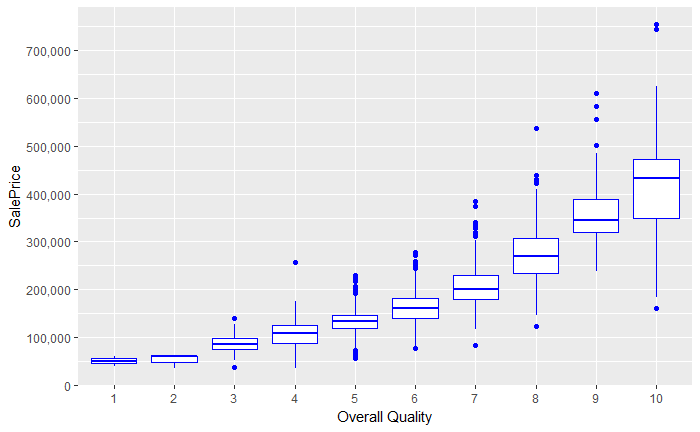

```r
# overall quality
ggplot(data = all[!is.na(all$SalePrice),], aes(x=factor(OverallQual), y=SalePrice)) +
      geom_boxplot(col="blue") + labs(x="Overall Quality") +
      scale_y_continuous(breaks = seq(0, 800000, by=100000), labels = comma)
```

From this figure, the positive correlation is certainly there indeed, and seems to be slightly upward curve. Regarding outliers, there are no extreme values (1 data point in grade 4 can ve considered as outlier)

4.2.3 Above Grade (Ground) Living Area (square feet)

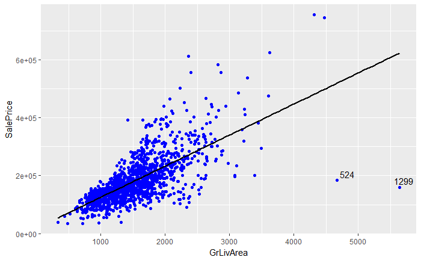

```r
#Above Grade (Ground) Living Area (square feet)
ggplot(data = all[!is.na(all$SalePrice),], aes(x=GrLivArea, y=SalePrice)) +
      geom_point(col="blue") +
      geom_smooth(method = "lm", se=FALSE, color="black", aes(group=1)) +
      #scale_y_continuous(breaks = seq(0, 800000, by=100000), labels = comma) +
      geom_text_repel(aes(label=ifelse(all$GrLivArea[!is.na(all$SalePrice)]>4500, rownames(all), "")))
```

There are 2 house with really big living areas and low SalesPrices seem outliers (these house score maximum points on Overall Quality)

```r
all[c(524, 1299), c("SalePrice", "GrLivArea", "OverallQual")]
```

|  | SalePrice | GrLivArea | OverallQual |
| --- | --- | --- | --- |
| 524 | 184750 | 4676 | 10 |
| 1299 | 160000 | 5642 | 10 |

5. Next, consider missing data, label encoding, and factorizing variables 5.1 Completeness of the data

```r
naCol <- which(colSums(is.na(all)) > 0)
sort(colSums(sapply(all[naCol], is.na)), decreasing = TRUE)
```

```
      PoolQC  MiscFeature        Alley        Fence    SalePrice  FireplaceQu  LotFrontage  GarageYrBlt GarageFinish   GarageQual   GarageCond   GarageType
        2909         2814         2721         2348         1459         1420          486          159          159          159          159          157
    BsmtCond BsmtExposure     BsmtQual BsmtFinType2 BsmtFinType1   MasVnrType   MasVnrArea     MSZoning    Utilities BsmtFullBath BsmtHalfBath   Functional
          82           82           81           80           79           24           23            4            2            2            2            2
 Exterior1st  Exterior2nd   BsmtFinSF1   BsmtFinSF2    BsmtUnfSF  TotalBsmtSF   Electrical  KitchenQual   GarageCars   GarageArea     SaleType
           1            1            1            1            1            1            1            1            1            1            1
```

```r
cat("There are", length(naCol), "columns with missing values")
```

```
There are 35 columns with missing values
```

5.2. Imputing missing data

Pool Quality and the PoolArea variable

```r
all$PoolQC[is.na(all$PoolQC)] <- "None"
# Label encode as the values are ordinal
Qualities <- c("None"=0, "Po"=1, "Fa"=2, "TA"=3, "Gd"=4, "Ex"=5)
all$PoolQC <- as.integer(revalue(all$PoolQC, Qualities))
table(all$PoolQC)
```

```
   0    2    4    5
2909    2    4    4
```

There are no clear relation between PoolArea and PoolQC -> impite PoolQC values vased on the Overall Quality

```r
all[all$PoolArea>0 & all$PoolQC==0, c("PoolArea", "PoolQC", "OverallQual")]
```

|  | PoolArea | PoolQC | OverallQual |
| --- | --- | --- | --- |
| 2421 | 368 | 0 | 4 |
| 2504 | 444 | 0 | 6 |
| 2600 | 561 | 0 | 3 |

```r
all$PoolQC[2421] <- 2
all$PoolQC[2504] <- 3
all$PoolQC[2600] <- 2
```

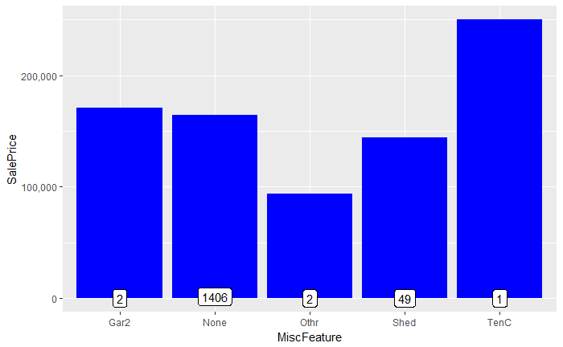

```r
all$MiscFeature[is.na(all$MiscFeature)] <- 'None'
all$MiscFeature <- as.factor(all$MiscFeature)
ggplot(all[!is.na(all$SalePrice),], aes(x=MiscFeature, y=SalePrice)) +
        geom_bar(stat='summary', fun.y = "median", fill='blue') +
        scale_y_continuous(breaks= seq(0, 800000, by=100000), labels = comma) +
        geom_label(stat = "count", aes(label = ..count.., y = ..count..))
```

```r
table(all$MiscFeature)
```

```
Gar2 None Othr Shed TenC
   5 2814    4   95    1
```

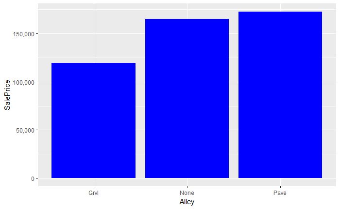

```r
all$Alley[is.na(all$Alley)] <- 'None'
all$Alley <- as.factor(all$Alley)
ggplot(all[!is.na(all$SalePrice),], aes(x=Alley, y=SalePrice)) +
        geom_bar(stat='summary', fun.y = "median", fill='blue')+
        scale_y_continuous(breaks= seq(0, 200000, by=50000), labels = comma)
```

```r
table(all$Alley)
```

```
Grvl None Pave
 120 2721   78
```

```r
all$Fence[is.na(all$Fence)] <- 'None'
table(all$Fence)
```

```
GdPrv  GdWo MnPrv  MnWw  None
  118   112   329    12  2348
```

```r
all[!is.na(all$SalePrice),] %>% group_by(Fence) %>% summarise(median = median(SalePrice), counts=n())
```

| Fence | median | counts |
| --- | --- | --- |
| GdPrv | 167500 | 59 |
| GdWo | 138750 | 54 |
| MnPrv | 137450 | 157 |
| MnWw | 130000 | 11 |
| None | 173000 | 1179 |

```r
#My conclusion is that the values do not seem ordinal (no fence is best). Therefore, I will convert Fence into a factor.
all$Fence <- as.factor(all$Fence)
```

```r
all$FireplaceQu[is.na(all$FireplaceQu)] <- 'None'
all$FireplaceQu<-as.integer(revalue(all$FireplaceQu, Qualities))
table(all$FireplaceQu)
```

```
   0    1    2    3    4    5
1420   46   74  592  744   43
```

```r
table(all$Fireplaces)
```

```
   0    1    2    3    4
1420 1268  219   11    1
```

```r
sum(table(all$Fireplaces))
```

```
[1] 2919
```

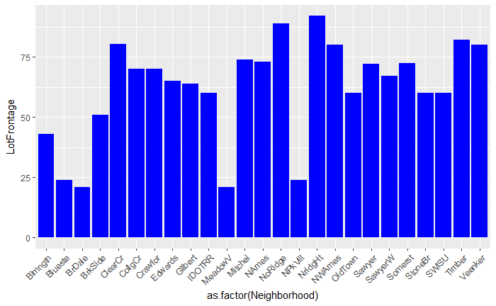

```r
ggplot(all[!is.na(all$LotFrontage),], aes(x=as.factor(Neighborhood), y=LotFrontage)) +
        geom_bar(stat='summary', fun.y = "median", fill='blue') +
        theme(axis.text.x = element_text(angle = 45, hjust = 1))
```

```r
for (i in 1:nrow(all)){
        if(is.na(all$LotFrontage[i])){
               all$LotFrontage[i] <- as.integer(median(all$LotFrontage[all$Neighborhood==all$Neighborhood[i]], na.rm=TRUE))
        }
}
```

```r
all$LotShape<-as.integer(revalue(all$LotShape, c('IR3'=0, 'IR2'=1, 'IR1'=2, 'Reg'=3)))
table(all$LotShape)
```

```
   0    1    2    3
  16   76  968 1859
```

```r
sum(table(all$LotShape))
```

```
[1] 2919
```

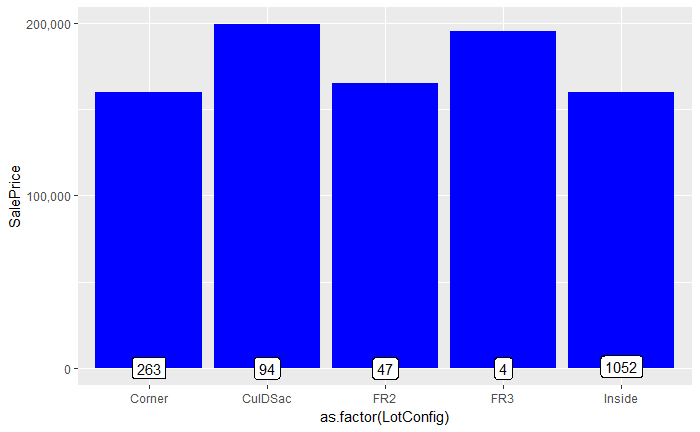

```r
ggplot(all[!is.na(all$SalePrice),], aes(x=as.factor(LotConfig), y=SalePrice)) +
        geom_bar(stat='summary', fun.y = "median", fill='blue')+
        scale_y_continuous(breaks= seq(0, 800000, by=100000), labels = comma) +
        geom_label(stat = "count", aes(label = ..count.., y = ..count..))
```

The values seemed possibly ordinal to me, but the visualization does not show this. Therefore, I will convert the variable into a factor.

```r
all$LotConfig <- as.factor(all$LotConfig)
table(all$LotConfig)
```

```
 Corner CulDSac     FR2     FR3  Inside
    511     176      85      14    2133
```

```r
sum(table(all$LotConfig))
```

```
[1] 2919
```

Garage variables Altogether, there are 7 variables related to garages Two of those have one NA (GarageCars and GarageArea), one has 157 NAs (GarageType), 4 variables have 159 NAs.

First of all, I am going to replace all 159 missing GarageYrBlt: Year garage was built values with the values in YearBuilt (this is similar to YearRemodAdd, which also defaults to YearBuilt if no remodeling or additions).

```r
all$GarageYrBlt[is.na(all$GarageYrBlt)] <- all$YearBuilt[is.na(all$GarageYrBlt)]
#check if all 157 NAs are the same observations among the variables with 157/159 NAs
length(which(is.na(all$GarageType) & is.na(all$GarageFinish) & is.na(all$GarageCond) & is.na(all$GarageQual)))
```

```
[1] 157
```

```r
#Find the 2 additional NAs
kable(all[!is.na(all$GarageType) & is.na(all$GarageFinish), c('GarageCars', 'GarageArea', 'GarageType', 'GarageCond', 'GarageQual', 'GarageFinish')])
```

|  | GarageCars | GarageArea | GarageType | GarageCond | GarageQual | GarageFinish |
| --- | --- | --- | --- | --- | --- | --- |
| 2127 | 1 | 360 | Detchd | NA | NA | NA |
| 2577 | NA | NA | Detchd | NA | NA | NA |

The 157 NAs within GarageType all turn out to be NA in GarageCondition, GarageQuality, and GarageFinish as well. The differences are found in houses 2127 and 2577. As you can see, house 2127 actually does seem to have a Garage and house 2577 does not. Therefore, there should be 158 houses without a Garage. To fix house 2127, I will imputate the most common values (modes) for GarageCond, GarageQual, and GarageFinish.

```r
#Imputing modes.
all$GarageCond[2127] <- names(sort(-table(all$GarageCond)))[1]
all$GarageQual[2127] <- names(sort(-table(all$GarageQual)))[1]
all$GarageFinish[2127] <- names(sort(-table(all$GarageFinish)))[1]
#display "fixed" house
kable(all[2127, c('GarageYrBlt', 'GarageCars', 'GarageArea', 'GarageType', 'GarageCond', 'GarageQual', 'GarageFinish')])
```

|  | GarageYrBlt | GarageCars | GarageArea | GarageType | GarageCond | GarageQual | GarageFinish |
| --- | --- | --- | --- | --- | --- | --- | --- |
| 2127 | 1910 | 1 | 360 | Detchd | TA | TA | Unf |

```r
#fixing 3 values for house 2577
all$GarageCars[2577] <- 0
all$GarageArea[2577] <- 0
all$GarageType[2577] <- NA
#check if NAs of the character variables are now all 158
length(which(is.na(all$GarageType) & is.na(all$GarageFinish) & is.na(all$GarageCond) & is.na(all$GarageQual)))
```

```
[1] 158
```

```r
all$GarageType[is.na(all$GarageType)] <- 'No Garage'
all$GarageType <- as.factor(all$GarageType)
table(all$GarageType)
```

```
   2Types    Attchd   Basment   BuiltIn   CarPort    Detchd No Garage
       23      1723        36       186        15       778       158
```

```r
all$GarageFinish[is.na(all$GarageFinish)] <- 'None'
Finish <- c('None'=0, 'Unf'=1, 'RFn'=2, 'Fin'=3)
all$GarageFinish<-as.integer(revalue(all$GarageFinish, Finish))
table(all$GarageFinish)
```

```
   0    1    2    3
 158 1231  811  719
```

```r
all$GarageQual[is.na(all$GarageQual)] <- 'None'
all$GarageQual<-as.integer(revalue(all$GarageQual, Qualities))
table(all$GarageQual)
```

```
   0    1    2    3    4    5
 158    5  124 2605   24    3
```

```r
all$GarageCond[is.na(all$GarageCond)] <- 'None'
all$GarageCond<-as.integer(revalue(all$GarageCond, Qualities))
table(all$GarageCond)
```

```
   0    1    2    3    4    5
 158   14   74 2655   15    3
```

```r
#check if all 79 NAs are the same observations among the variables with 80+ NAs
length(which(is.na(all$BsmtQual) & is.na(all$BsmtCond) & is.na(all$BsmtExposure) & is.na(all$BsmtFinType1) & is.na(all$BsmtFinType2)))
```

```
[1] 79
```

```r
#Find the additional NAs; BsmtFinType1 is the one with 79 NAs
all[!is.na(all$BsmtFinType1) & (is.na(all$BsmtCond)|is.na(all$BsmtQual)|is.na(all$BsmtExposure)|is.na(all$BsmtFinType2)), c('BsmtQual', 'BsmtCond', 'BsmtExposure', 'BsmtFinType1', 'BsmtFinType2')]
```

|  | BsmtQual | BsmtCond | BsmtExposure | BsmtFinType1 | BsmtFinType2 |
| --- | --- | --- | --- | --- | --- |
| 333 | Gd | TA | No | GLQ | NA |
| 949 | Gd | TA | NA | Unf | Unf |
| 1488 | Gd | TA | NA | Unf | Unf |
| 2041 | Gd | NA | Mn | GLQ | Rec |
| 2186 | TA | NA | No | BLQ | Unf |
| 2218 | NA | Fa | No | Unf | Unf |
| 2219 | NA | TA | No | Unf | Unf |
| 2349 | Gd | TA | NA | Unf | Unf |
| 2525 | TA | NA | Av | ALQ | Unf |

So altogether, it seems as if there are 79 houses without a basement, because the basement variables of the other houses with missing values are all 80% complete (missing 1 out of 5 values). I am going to impute the modes to fix those 9 houses.

```r
#Imputing modes.
all$BsmtFinType2[333] <- names(sort(-table(all$BsmtFinType2)))[1]
all$BsmtExposure[c(949, 1488, 2349)] <- names(sort(-table(all$BsmtExposure)))[1]
all$BsmtCond[c(2041, 2186, 2525)] <- names(sort(-table(all$BsmtCond)))[1]
all$BsmtQual[c(2218, 2219)] <- names(sort(-table(all$BsmtQual)))[1]
```

```r
all$BsmtQual[is.na(all$BsmtQual)] <- 'None'
all$BsmtQual<-as.integer(revalue(all$BsmtQual, Qualities))
table(all$BsmtQual)
```

```
   0    2    3    4    5
  79   88 1285 1209  258
```

```r
all$BsmtCond[is.na(all$BsmtCond)] <- 'None'
all$BsmtCond<-as.integer(revalue(all$BsmtCond, Qualities))
table(all$BsmtCond)
```

```
   0    1    2    3    4
  79    5  104 2609  122
```

```r
all$BsmtExposure[is.na(all$BsmtExposure)] <- 'None'
Exposure <- c('None'=0, 'No'=1, 'Mn'=2, 'Av'=3, 'Gd'=4)
all$BsmtExposure<-as.integer(revalue(all$BsmtExposure, Exposure))
table(all$BsmtExposure)
```

```
   0    1    2    3    4
  79 1907  239  418  276
```

```r
all$BsmtFinType1[is.na(all$BsmtFinType1)] <- 'None'
FinType <- c('None'=0, 'Unf'=1, 'LwQ'=2, 'Rec'=3, 'BLQ'=4, 'ALQ'=5, 'GLQ'=6)
all$BsmtFinType1<-as.integer(revalue(all$BsmtFinType1, FinType))
table(all$BsmtFinType1)
```

```
  0   1   2   3   4   5   6
 79 851 154 288 269 429 849
```

```r
all$BsmtFinType2[is.na(all$BsmtFinType2)] <- 'None'
FinType <- c('None'=0, 'Unf'=1, 'LwQ'=2, 'Rec'=3, 'BLQ'=4, 'ALQ'=5, 'GLQ'=6)
all$BsmtFinType2<-as.integer(revalue(all$BsmtFinType2, FinType))
table(all$BsmtFinType2)
```

```
   0    1    2    3    4    5    6
  79 2494   87  105   68   52   34
```

```r
#display remaining NAs. Using BsmtQual as a reference for the 79 houses without basement agreed upon earlier
all[(is.na(all$BsmtFullBath)|is.na(all$BsmtHalfBath)|is.na(all$BsmtFinSF1)|is.na(all$BsmtFinSF2)|is.na(all$BsmtUnfSF)|is.na(all$TotalBsmtSF)), c('BsmtQual', 'BsmtFullBath', 'BsmtHalfBath', 'BsmtFinSF1', 'BsmtFinSF2', 'BsmtUnfSF', 'TotalBsmtSF')]
```

|  | BsmtQual | BsmtFullBath | BsmtHalfBath | BsmtFinSF1 | BsmtFinSF2 | BsmtUnfSF | TotalBsmtSF |
| --- | --- | --- | --- | --- | --- | --- | --- |
| 2121 | 0 | NA | NA | NA | NA | NA | NA |
| 2189 | 0 | NA | NA | 0 | 0 | 0 | 0 |

```r
all$BsmtFullBath[is.na(all$BsmtFullBath)] <-0
table(all$BsmtFullBath)
```

```
   0    1    2    3
1707 1172   38    2
```

```r
all$BsmtHalfBath[is.na(all$BsmtHalfBath)] <-0
table(all$BsmtHalfBath)
```

```
   0    1    2
2744  171    4
```

```r
all$BsmtFinSF1[is.na(all$BsmtFinSF1)] <-0
all$BsmtFinSF2[is.na(all$BsmtFinSF2)] <-0
all$BsmtUnfSF[is.na(all$BsmtUnfSF)] <-0
all$TotalBsmtSF[is.na(all$TotalBsmtSF)] <-0
```

Masonry veneer type has 24 NAs. Masonry veneer area has 23 NAs. If a house has a veneer area, it should also have a masonry veneer type. Let’s fix this one first.

```r
#check if the 23 houses with veneer area NA are also NA in the veneer type
length(which(is.na(all$MasVnrType) & is.na(all$MasVnrArea)))
```

```
[1] 23
```

```r
#find the one that should have a MasVnrType
all[is.na(all$MasVnrType) & !is.na(all$MasVnrArea), c('MasVnrType', 'MasVnrArea')]
```

|  | MasVnrType | MasVnrArea |
| --- | --- | --- |
| 2611 | NA | 198 |

```r
#fix this veneer type by imputing the mode
all$MasVnrType[2611] <- names(sort(-table(all$MasVnrType)))[2] #taking the 2nd value as the 1st is 'none'
all[2611, c('MasVnrType', 'MasVnrArea')]
```

|  | MasVnrType | MasVnrArea |
| --- | --- | --- |
| 2611 | BrkFace | 198 |

```r
all$MasVnrType[is.na(all$MasVnrType)] <- 'None'
all[!is.na(all$SalePrice),] %>% group_by(MasVnrType) %>% summarise(median = median(SalePrice), counts=n()) %>% arrange(median)
```

| MasVnrType | median | counts |
| --- | --- | --- |
| BrkCmn | 139000 | 15 |
| None | 143125 | 872 |
| BrkFace | 181000 | 445 |
| Stone | 246839 | 128 |

There seems to be a significant difference between “common brick/none” and the other types. I assume that simple stones and for instance wooden houses are just cheaper. I will make the ordinality accordingly.

```r
Masonry <- c('None'=0, 'BrkCmn'=0, 'BrkFace'=1, 'Stone'=2)
all$MasVnrType<-as.integer(revalue(all$MasVnrType, Masonry))
table(all$MasVnrType)
```

```
   0    1    2
1790  880  249
```

```r
all$MasVnrArea[is.na(all$MasVnrArea)] <-0
```

```r
#imputing the mode
all$MSZoning[is.na(all$MSZoning)] <- names(sort(-table(all$MSZoning)))[1]
all$MSZoning <- as.factor(all$MSZoning)
table(all$MSZoning)
```

```
C (all)      FV      RH      RL      RM
     25     139      26    2269     460
```

```r
sum(table(all$MSZoning))
```

```
[1] 2919
```

```r
all$KitchenQual[is.na(all$KitchenQual)] <- 'TA' #replace with most common value
all$KitchenQual<-as.integer(revalue(all$KitchenQual, Qualities))
table(all$KitchenQual)
```

```
   2    3    4    5
  70 1493 1151  205
```

```r
sum(table(all$KitchenQual))
```

```
[1] 2919
```

```r
table(all$KitchenAbvGr)
```

```
   0    1    2    3
   3 2785  129    2
```

```r
sum(table(all$KitchenAbvGr))
```

```
[1] 2919
```

However, the table below shows that only one house does not have all public utilities. This house is in the train set. Therefore, imputing ‘AllPub’ for the NAs means that all houses in the test set will have ‘AllPub’. This makes the variable useless for prediction. Consequently, I will get rid of it.

```r
table(all$Utilities)
```

```
AllPub NoSeWa
  2916      1
```

```r
kable(all[is.na(all$Utilities) | all$Utilities=='NoSeWa', 1:9])
```

|  | MSSubClass | MSZoning | LotFrontage | LotArea | Street | Alley | LotShape | LandContour | Utilities |
| --- | --- | --- | --- | --- | --- | --- | --- | --- | --- |
| 945 | 20 | RL | 82 | 14375 | Pave | None | 2 | Lvl | NoSeWa |
| 1916 | 30 | RL | 109 | 21780 | Grvl | None | 3 | Lvl | NA |
| 1946 | 20 | RL | 64 | 31220 | Pave | None | 2 | Bnk | NA |

```r
all$Utilities <- NULL
```

```r
#impute mode for the 1 NA
all$Functional[is.na(all$Functional)] <- names(sort(-table(all$Functional)))[1]
all$Functional <- as.integer(revalue(all$Functional, c('Sal'=0, 'Sev'=1, 'Maj2'=2, 'Maj1'=3, 'Mod'=4, 'Min2'=5, 'Min1'=6, 'Typ'=7)))
table(all$Functional)
```

```
   1    2    3    4    5    6    7
   2    9   19   35   70   65 2719
```

```r
sum(table(all$Functional))
```

```
[1] 2919
```

```r
#imputing mode
all$Exterior1st[is.na(all$Exterior1st)] <- names(sort(-table(all$Exterior1st)))[1]
all$Exterior1st <- as.factor(all$Exterior1st)
table(all$Exterior1st)
```

```
AsbShng AsphShn BrkComm BrkFace  CBlock CemntBd HdBoard ImStucc MetalSd Plywood   Stone  Stucco VinylSd Wd Sdng WdShing
     44       2       6      87       2     126     442       1     450     221       2      43    1026     411      56
```

```r
sum(table(all$Exterior1st))
```

```
[1] 2919
```

```r
#imputing mode
all$Exterior2nd[is.na(all$Exterior2nd)] <- names(sort(-table(all$Exterior2nd)))[1]
all$Exterior2nd <- as.factor(all$Exterior2nd)
table(all$Exterior2nd)
```

```
AsbShng AsphShn Brk Cmn BrkFace  CBlock CmentBd HdBoard ImStucc MetalSd   Other Plywood   Stone  Stucco VinylSd Wd Sdng Wd Shng
     38       4      22      47       3     126     406      15     447       1     270       6      47    1015     391      81
```

```r
sum(table(all$Exterior2nd))
```

```
[1] 2919
```

```r
all$ExterQual<-as.integer(revalue(all$ExterQual, Qualities))
## The following `from` values were not present in `x`: None, Po
table(all$ExterQual)
```

```
   2    3    4    5
  35 1798  979  107
```

```r
sum(table(all$ExterQual))
```

```
[1] 2919
```

```r
all$ExterCond<-as.integer(revalue(all$ExterCond, Qualities))
## The following `from` values were not present in `x`: None
table(all$ExterCond)
```

```
   1    2    3    4    5
   3   67 2538  299   12
```

```r
sum(table(all$ExterCond))
```

```
[1] 2919
```

```r
#imputing mode
all$Electrical[is.na(all$Electrical)] <- names(sort(-table(all$Electrical)))[1]
all$Electrical <- as.factor(all$Electrical)
table(all$Electrical)
```

```
FuseA FuseF FuseP   Mix SBrkr
  188    50     8     1  2672
```

```r
sum(table(all$Electrical))
```

```
[1] 2919
```

```r
#imputing mode
all$SaleType[is.na(all$SaleType)] <- names(sort(-table(all$SaleType)))[1]
all$SaleType <- as.factor(all$SaleType)
table(all$SaleType)
```

```
  COD   Con ConLD ConLI ConLw   CWD   New   Oth    WD
   87     5    26     9     8    12   239     7  2526
```

```r
sum(table(all$SaleType))
```

```
[1] 2919
```

```r
all$SaleCondition <- as.factor(all$SaleCondition)
table(all$SaleCondition)
```

```
Abnorml AdjLand  Alloca  Family  Normal Partial
    190      12      24      46    2402     245
```

```r
sum(table(all$SaleCondition))
```

```
[1] 2919
```

5.3 Label encoding/factorizing the remaining character variables

```r
charCol <- names(all[, sapply(all, is.character)])
charCol
```

```
 [1] "Street"       "LandContour"  "LandSlope"    "Neighborhood" "Condition1"   "Condition2"   "BldgType"     "HouseStyle"   "RoofStyle"    "RoofMatl"
[11] "Foundation"   "Heating"      "HeatingQC"    "CentralAir"   "PavedDrive"
```

```r
cat ("There are", length(charCol), "remaining columns with character values")
```

```
There are 15 remaining columns with character values
```

```r
#No ordinality, so converting into factors
all$Foundation <- as.factor(all$Foundation)
table(all$Foundation)
```

```
BrkTil CBlock  PConc   Slab  Stone   Wood
   311   1235   1308     49     11      5
```

```r
sum(table(all$Foundation))
```

```
[1] 2919
```

```r
#No ordinality, so converting into factors
all$Heating <- as.factor(all$Heating)
table(all$Heating)
```

```
Floor  GasA  GasW  Grav  OthW  Wall
    1  2874    27     9     2     6
```

```r
sum(table(all$Heating))
```

```
[1] 2919
```

```r
#making the variable ordinal using the Qualities vector
all$HeatingQC<-as.integer(revalue(all$HeatingQC, Qualities))
## The following `from` values were not present in `x`: None
table(all$HeatingQC)
```

```
   1    2    3    4    5
   3   92  857  474 1493
```

```r
sum(table(all$HeatingQC))
```

```
[1] 2919
```

```r
all$CentralAir<-as.integer(revalue(all$CentralAir, c('N'=0, 'Y'=1)))
table(all$CentralAir)
```

```
   0    1
 196 2723
```

```r
sum(table(all$CentralAir))
```

```
[1] 2919
```

```r
#No ordinality, so converting into factors
all$RoofStyle <- as.factor(all$RoofStyle)
table(all$RoofStyle)#No ordinality, so converting into factors
```

```
   Flat   Gable Gambrel     Hip Mansard    Shed
     20    2310      22     551      11       5
```

```r
all$RoofMatl <- as.factor(all$RoofMatl)
table(all$RoofMatl)
```

```
ClyTile CompShg Membran   Metal    Roll Tar&Grv WdShake WdShngl
      1    2876       1       1       1      23       9       7
```

```r
sum(table(all$RoofStyle))
```

```
[1] 2919
```

```r
#No ordinality, so converting into factors
all$RoofMatl <- as.factor(all$RoofMatl)
table(all$RoofMatl)
```

```
ClyTile CompShg Membran   Metal    Roll Tar&Grv WdShake WdShngl
      1    2876       1       1       1      23       9       7
```

```r
sum(table(all$RoofMatl))
```

```
[1] 2919
```

```r
#No ordinality, so converting into factors
all$LandContour <- as.factor(all$LandContour)
table(all$LandContour)
```

```
 Bnk  HLS  Low  Lvl
 117  120   60 2622
```

```r
sum(table(all$LandContour))
```

```
[1] 2919
```

```r
#Ordinal, so label encoding
all$LandSlope<-as.integer(revalue(all$LandSlope, c('Sev'=0, 'Mod'=1, 'Gtl'=2)))
table(all$LandSlope)
```

```
   0    1    2
  16  125 2778
```

```r
sum(table(all$LandSlope))
```

```
[1] 2919
```

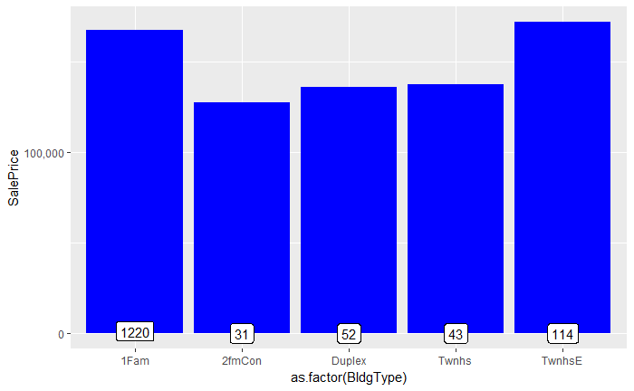

```r
# BldgType: Type of dwelling seems ordinal (single family detached=best). Let’s check it with visualization.
ggplot(all[!is.na(all$SalePrice),], aes(x=as.factor(BldgType), y=SalePrice)) +
        geom_bar(stat='summary', fun.y = "median", fill='blue')+
        scale_y_continuous(breaks= seq(0, 800000, by=100000), labels = comma) +
        geom_label(stat = "count", aes(label = ..count.., y = ..count..))
```

However, the visualization does not show ordinality.

```r
#No ordinality, so converting into factors
all$BldgType <- as.factor(all$BldgType)
table(all$BldgType)
```

```
  1Fam 2fmCon Duplex  Twnhs TwnhsE
  2425     62    109     96    227
```

```r
sum(table(all$BldgType))
```

```
[1] 2919
```

```r
#No ordinality, so converting into factors
all$HouseStyle <- as.factor(all$HouseStyle)
table(all$HouseStyle)
```

```
1.5Fin 1.5Unf 1Story 2.5Fin 2.5Unf 2Story SFoyer   SLvl
   314     19   1471      8     24    872     83    128
```

```r
sum(table(all$HouseStyle))
```

```
[1] 2919
```

```r
#No ordinality, so converting into factors
all$Neighborhood <- as.factor(all$Neighborhood)
table(all$Neighborhood)
```

```
Blmngtn Blueste  BrDale BrkSide ClearCr CollgCr Crawfor Edwards Gilbert  IDOTRR MeadowV Mitchel   NAmes NoRidge NPkVill NridgHt  NWAmes OldTown  Sawyer SawyerW
     28      10      30     108      44     267     103     194     165      93      37     114     443      71      23     166     131     239     151     125
Somerst StoneBr   SWISU  Timber Veenker
    182      51      48      72      24
```

```r
sum(table(all$Neighborhood))
```

```
[1] 2919
```

```r
#No ordinality, so converting into factors
all$Condition1 <- as.factor(all$Condition1)
table(all$Condition1)
```

```
Artery  Feedr   Norm   PosA   PosN   RRAe   RRAn   RRNe   RRNn
    92    164   2511     20     39     28     50      6      9
```

```r
sum(table(all$Condition1))
```

```
[1] 2919
```

```r
#No ordinality, so converting into factors
all$Condition2 <- as.factor(all$Condition2)
table(all$Condition2)
```

```
Artery  Feedr   Norm   PosA   PosN   RRAe   RRAn   RRNn
     5     13   2889      4      4      1      1      2
```

```r
sum(table(all$Condition2))
```

```
[1] 2919
```

```r
#Ordinal, so label encoding
all$Street<-as.integer(revalue(all$Street, c('Grvl'=0, 'Pave'=1)))
table(all$Street)
```

```
   0    1
  12 2907
```

```r
sum(table(all$Street))
```

```
[1] 2919
```

```r
#Ordinal, so label encoding
all$PavedDrive<-as.integer(revalue(all$PavedDrive, c('N'=0, 'P'=1, 'Y'=2)))
table(all$PavedDrive)
```

```
   0    1    2
 216   62 2641
```

```r
sum(table(all$PavedDrive))
```

```
[1] 2919
```

5.4 Changing some numeric variables into factors At this point, all variables are complete (No NAs), and all character variables are converted into either numeric labels of into factors. However, there are 3 variables that are recorded numeric but should actually be categorical.

5.4.1 Year and Month Sold While oridinality within YearBuilt (or remodeled) makes sense (old houses are worth less), we are talking about only 5 years of sales. These years also include an economic crisis. For instance: Sale Prices in 2009 (after the collapse) are very likely to be much lower than in 2007. I wil convert YrSold into a factor before modeling, but as I need the numeric version of YrSold to create an Age variable, I am not doing that yet.

Month Sold is also an Integer variable. However, December is not “better” than January. Therefore, I will convert MoSold values back into factors.

```r
str(all$YrSold)
```

```
 int [1:2919] 2008 2007 2008 2006 2008 2009 2007 2009 2008 2008 ...
```

```r
str(all$MoSold)
```

```
 int [1:2919] 2 5 9 2 12 10 8 11 4 1 ...
```

```r
all$MoSold <- as.factor(all$MoSold)
```

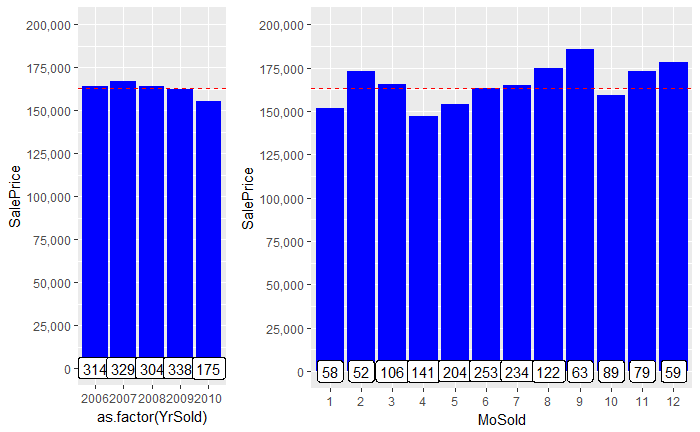

```r
ys <- ggplot(all[!is.na(all$SalePrice),], aes(x=as.factor(YrSold), y=SalePrice)) +
        geom_bar(stat='summary', fun.y = "median", fill='blue')+
        scale_y_continuous(breaks= seq(0, 800000, by=25000), labels = comma) +
        geom_label(stat = "count", aes(label = ..count.., y = ..count..)) +
        coord_cartesian(ylim = c(0, 200000)) +
        geom_hline(yintercept=163000, linetype="dashed", color = "red") #dashed line is median SalePrice
ms <- ggplot(all[!is.na(all$SalePrice),], aes(x=MoSold, y=SalePrice)) +
        geom_bar(stat='summary', fun.y = "median", fill='blue')+
        scale_y_continuous(breaks= seq(0, 800000, by=25000), labels = comma) +
        geom_label(stat = "count", aes(label = ..count.., y = ..count..)) +
        coord_cartesian(ylim = c(0, 200000)) +
        geom_hline(yintercept=163000, linetype="dashed", color = "red") #dashed line is median SalePrice
grid.arrange(ys, ms, widths=c(1,2))
```

Although possible a bit less steep than expected, the effects of the Banking crises that took place at the end of 2007 can be seen indeed. After the highest median prices in 2007, the prices gradually decreased. However, seasonality seems to play a bigger role, as you can see above

```r
str(all$MSSubClass)
```

```
 int [1:2919] 60 20 60 70 60 50 20 60 50 190 ...
```

```r
all$MSSubClass <- as.factor(all$MSSubClass)
#revalue for better readability
all$MSSubClass<-revalue(all$MSSubClass, c('20'='1 story 1946+', '30'='1 story 1945-', '40'='1 story unf attic', '45'='1,5 story unf', '50'='1,5 story fin', '60'='2 story 1946+', '70'='2 story 1945-', '75'='2,5 story all ages', '80'='split/multi level', '85'='split foyer', '90'='duplex all style/age', '120'='1 story PUD 1946+', '150'='1,5 story PUD all', '160'='2 story PUD 1946+', '180'='PUD multilevel', '190'='2 family conversion'))
str(all$MSSubClass)
```

```
 Factor w/ 16 levels "1 story 1946+",..: 6 1 6 7 6 5 1 6 5 16 ...
```

6 Visualization of important variables

I have now finally reached the point where all character variables have been converted into categorical factors or have been label encoded into numbers. In addition, 3 numeric variables have been converted into factors, and I deleted one variable (Utilities). As you can see below, the number of numerical variables is now 56 (including the response variable), and the remaining 23 variables are categorical.

```r
numericVars <- which(sapply(all, is.numeric)) #index vector numeric variables
factorVars <- which(sapply(all, is.factor)) #index vector factor variables
cat('There are', length(numericVars), 'numeric variables, and', length(factorVars), 'categoric variables')
```

```
There are 56 numeric variables, and 23 categoric variables
```

6.1 Correlations again Below I am checking the correlations again. As you can see, the number of variables with a correlation of at least 0.5 with the SalePrice has increased from 10 (see section 4.2.1) to 16.

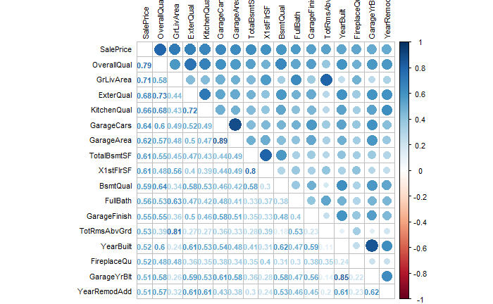

```r
all_numVar <- all[, numericVars]
cor_numVar <- cor(all_numVar, use="pairwise.complete.obs") #correlations of all numeric variables
#sort on decreasing correlations with SalePrice
cor_sorted <- as.matrix(sort(cor_numVar[,'SalePrice'], decreasing = TRUE))
 #select only high corelations
CorHigh <- names(which(apply(cor_sorted, 1, function(x) abs(x)>0.5)))
cor_numVar <- cor_numVar[CorHigh, CorHigh]
corrplot.mixed(cor_numVar, tl.col="black", tl.pos = "lt", tl.cex = 0.7,cl.cex = .7, number.cex=.7)
```

6.2 Finding variable importance with a quick Random Forest Although the correlations are giving a good overview of the most important numeric variables and multicolinerity among those variables, I wanted to get an overview of the most important variables including the categorical variables before moving on to visualization.

I tried to get the relative importance of variables with a quick linear regression model with the calc.relimp function of package , and also tried the boruta function of package boruta which separates the variables into groups that are important or not. However, these method took a long time. As I only want to get an indication of the variable importance, I eventually decided to keep it simple and just use a quick and dirty Random Forest model with only 100 trees. This also does the job for me, and does not take very long as I can specify a (relatively) small number of trees.

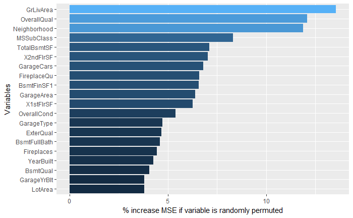

```r
set.seed(2018)
quick_RF <- randomForest(x=all[1:1460,-79], y=all$SalePrice[1:1460], ntree=100,importance=TRUE)
imp_RF <- importance(quick_RF)
imp_DF <- data.frame(Variables = row.names(imp_RF), MSE = imp_RF[,1])
imp_DF <- imp_DF[order(imp_DF$MSE, decreasing = TRUE),]
ggplot(imp_DF[1:20,], aes(x=reorder(Variables, MSE), y=MSE, fill=MSE)) + geom_bar(stat = 'identity') + labs(x = 'Variables', y= '% increase MSE if variable is randomly permuted') + coord_flip() + theme(legend.position="none")
```

6.2.1 Above Ground Living Area, and other surface related variables (in square feet)

```r
s1 <- ggplot(data= all, aes(x=GrLivArea)) +
        geom_density() + labs(x='Square feet living area')
s2 <- ggplot(data=all, aes(x=as.factor(TotRmsAbvGrd))) +
        geom_histogram(stat='count') + labs(x='Rooms above Ground')
```

```
Ignoring unknown parameters: binwidth, bins, pad
```

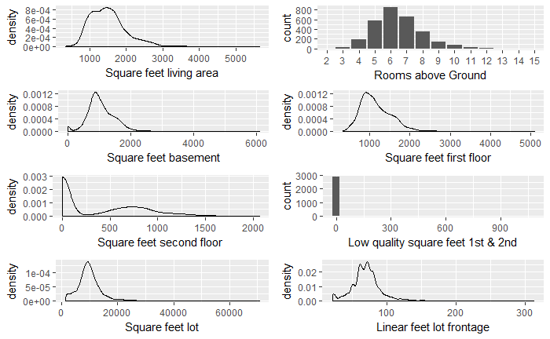

```r
s3 <- ggplot(data= all, aes(x=X1stFlrSF)) +
        geom_density() + labs(x='Square feet first floor')
s4 <- ggplot(data= all, aes(x=X2ndFlrSF)) +
        geom_density() + labs(x='Square feet second floor')
s5 <- ggplot(data= all, aes(x=TotalBsmtSF)) +
        geom_density() + labs(x='Square feet basement')
s6 <- ggplot(data= all[all$LotArea<100000,], aes(x=LotArea)) +
        geom_density() + labs(x='Square feet lot')
s7 <- ggplot(data= all, aes(x=LotFrontage)) +
        geom_density() + labs(x='Linear feet lot frontage')
s8 <- ggplot(data= all, aes(x=LowQualFinSF)) +
        geom_histogram() + labs(x='Low quality square feet 1st & 2nd')
layout <- matrix(c(1,2,5,3,4,8,6,7),4,2,byrow=TRUE)
multiplot(s1, s2, s3, s4, s5, s6, s7, s8, layout=layout)
```

```r
cor(all$GrLivArea, (all$X1stFlrSF + all$X2ndFlrSF + all$LowQualFinSF))
```

```
[1] 1
```

```r
head(all[all$LowQualFinSF>0, c('GrLivArea', 'X1stFlrSF', 'X2ndFlrSF', 'LowQualFinSF')])
```

|  | GrLivArea | X1stFlrSF | X2ndFlrSF | LowQualFinSF |
| --- | --- | --- | --- | --- |
| 52 | 1176 | 816 | 0 | 360 |
| 89 | 1526 | 1013 | 0 | 513 |
| 126 | 754 | 520 | 0 | 234 |
| 171 | 1382 | 854 | 0 | 528 |
| 186 | 3608 | 1518 | 1518 | 572 |
| 188 | 1656 | 808 | 704 | 144 |

6.2.2 The most important categorical variable; Neighborhood Th first graph shows the median SalePrice by Neighorhood. The frequency (number of houses) of each Neighborhood in the train set is shown in the labels.

The second graph below shows the frequencies across all data.

```r
n1 <- ggplot(all[!is.na(all$SalePrice),], aes(x=Neighborhood, y=SalePrice)) +
        geom_bar(stat='summary', fun.y = "median", fill='blue') +
        theme(axis.text.x = element_text(angle = 45, hjust = 1)) +
        scale_y_continuous(breaks= seq(0, 800000, by=50000), labels = comma) +
        geom_label(stat = "count", aes(label = ..count.., y = ..count..), size=3) +
        geom_hline(yintercept=163000, linetype="dashed", color = "red") #dashed line is median SalePrice
n2 <- ggplot(data=all, aes(x=Neighborhood)) +
        geom_histogram(stat='count')+
        geom_label(stat = "count", aes(label = ..count.., y = ..count..), size=3)+
        theme(axis.text.x = element_text(angle = 45, hjust = 1))
```

```
Ignoring unknown parameters: binwidth, bins, pad
```

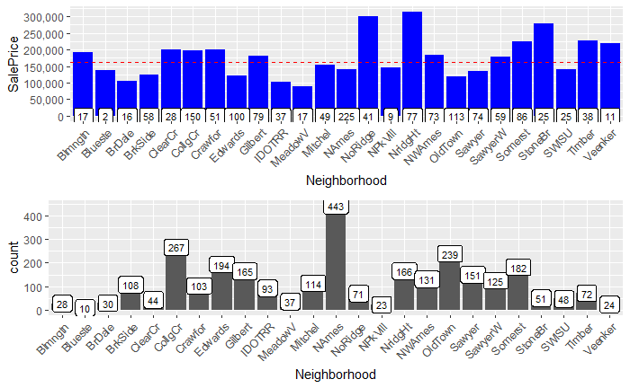

```r
grid.arrange(n1, n2)
```

6.2.3 Overall Quality, and other Quality variables I have already visualized the relation between Overall Quality and SalePrice in my initial explorations, but I want to visualize the frequency distribution as well. As there are more quality measurements, I am taking the opportunity to bundle them in this section.

```r
q1 <- ggplot(data=all, aes(x=as.factor(OverallQual))) +
        geom_histogram(stat='count')
```

```
Ignoring unknown parameters: binwidth, bins, pad
```

```r
q2 <- ggplot(data=all, aes(x=as.factor(ExterQual))) +
        geom_histogram(stat='count')
```

```
Ignoring unknown parameters: binwidth, bins, pad
```

```r
q3 <- ggplot(data=all, aes(x=as.factor(BsmtQual))) +
        geom_histogram(stat='count')
```

```
Ignoring unknown parameters: binwidth, bins, pad
```

```r
q4 <- ggplot(data=all, aes(x=as.factor(KitchenQual))) +
        geom_histogram(stat='count')
```

```
Ignoring unknown parameters: binwidth, bins, pad
```

```r
q5 <- ggplot(data=all, aes(x=as.factor(GarageQual))) +
        geom_histogram(stat='count')
```

```
Ignoring unknown parameters: binwidth, bins, pad
```

```r
q6 <- ggplot(data=all, aes(x=as.factor(FireplaceQu))) +
        geom_histogram(stat='count')
```

```
Ignoring unknown parameters: binwidth, bins, pad
```

```r
q7 <- ggplot(data=all, aes(x=as.factor(PoolQC))) +
        geom_histogram(stat='count')
```

```
Ignoring unknown parameters: binwidth, bins, pad
```

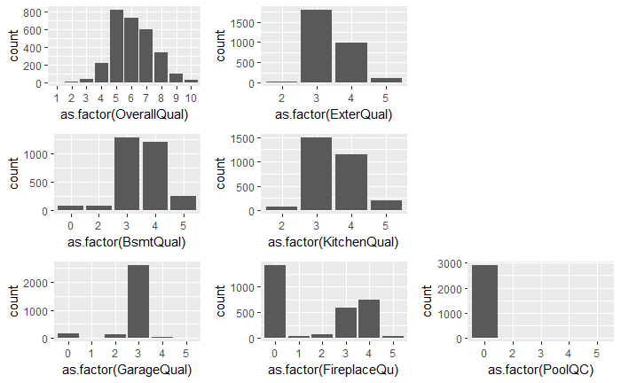

```r
layout <- matrix(c(1,2,8,3,4,8,5,6,7),3,3,byrow=TRUE)
multiplot(q1, q2, q3, q4, q5, q6, q7, layout=layout)
```

Overall Quality is very important, and also more granular than the other variables. External Quality is also improtant, but has a high correlation with Overall Quality (0.73). Kitchen Quality also seems one to keep, as all houses have a kitchen and there is a variance with some substance. Garage Quality does not seem to distinguish much, as the majority of garages have Q3. Fireplace Quality is in the list of high correlations, and in the important variables list. The PoolQC is just very sparse (the 13 pools cannot even be seen on this scale). I will look at creating a ‘has pool’ variable later on.

6.2.4 The second most important categorical variable; MSSubClass The first visualization shows the median SalePrice by MSSubClass. The frequency (number of houses) of each MSSubClass in the train set is shown in the labels.

The histrogram shows the frequencies across all data. Most houses are relatively new, and have one or two stories.

```r
ms1 <- ggplot(all[!is.na(all$SalePrice),], aes(x=MSSubClass, y=SalePrice)) +
        geom_bar(stat='summary', fun.y = "median", fill='blue') +
        theme(axis.text.x = element_text(angle = 45, hjust = 1)) +
        scale_y_continuous(breaks= seq(0, 800000, by=50000), labels = comma) +
        geom_label(stat = "count", aes(label = ..count.., y = ..count..), size=3) +
        geom_hline(yintercept=163000, linetype="dashed", color = "red") #dashed line is median SalePrice
ms2 <- ggplot(data=all, aes(x=MSSubClass)) +
        geom_histogram(stat='count')+
        geom_label(stat = "count", aes(label = ..count.., y = ..count..), size=3) +
        theme(axis.text.x = element_text(angle = 45, hjust = 1))
```

```
Ignoring unknown parameters: binwidth, bins, pad
```

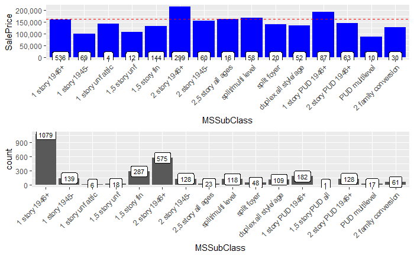

```r
grid.arrange(ms1, ms2)
```

6.2.5 Garage variables Several Garage variables have a high correlation with SalePrice, and are also in the top-20 list of the quick random forest. However, there is multicolinearity among them and I think that 7 garage variables is too many anyway. I feel that something like 3 variables should be sufficient (possibly GarageCars, GarageType, and a Quality measurement), but before I do any selection I am visualizing all of them in this section.

```r
#correct error
all$GarageYrBlt[2593] <- 2007 #this must have been a typo. GarageYrBlt=2207, YearBuilt=2006, YearRemodAdd=2007.
```

```r
g1 <- ggplot(data=all[all$GarageCars !=0,], aes(x=GarageYrBlt)) +
        geom_histogram()
g2 <- ggplot(data=all, aes(x=as.factor(GarageCars))) +
        geom_histogram(stat='count')
```

```
Ignoring unknown parameters: binwidth, bins, pad
```

```r
g3 <- ggplot(data= all, aes(x=GarageArea)) +
        geom_density()
g4 <- ggplot(data=all, aes(x=as.factor(GarageCond))) +
        geom_histogram(stat='count')
```

```
Ignoring unknown parameters: binwidth, bins, pad
```

```r
g5 <- ggplot(data=all, aes(x=GarageType)) +
        geom_histogram(stat='count')
```

```
Ignoring unknown parameters: binwidth, bins, pad
```

```r
g6 <- ggplot(data=all, aes(x=as.factor(GarageQual))) +
        geom_histogram(stat='count')
```

```
Ignoring unknown parameters: binwidth, bins, pad
```

```r
g7 <- ggplot(data=all, aes(x=as.factor(GarageFinish))) +
        geom_histogram(stat='count')
```

```
Ignoring unknown parameters: binwidth, bins, pad
```

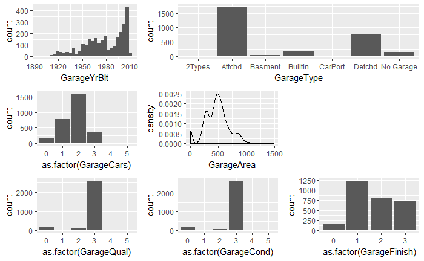

```r
layout <- matrix(c(1,5,5,2,3,8,6,4,7),3,3,byrow=TRUE)
multiplot(g1, g2, g3, g4, g5, g6, g7, layout=layout)
```

As already mentioned in section 4.2, GarageCars and GarageArea are highly correlated. Here, GarageQual and GarageCond also seem highly correlated, and both are dominated by level =3.

6.2.6 Basement variables Similar the garage variables, multiple basement variables are important in the correlations matrix and the Top 20 RF predictors list. However, 11 basement variables seems an overkill. Before I decide what I am going to do with them, I am visualizing 8 of them below. The 2 “Bathroom” variables are dealt with in Feature Engineering (section 7.1), and the “Basement square feet” is already discussed in section 6.2.1.

```r
b1 <- ggplot(data=all, aes(x=BsmtFinSF1)) +
        geom_histogram() + labs(x='Type 1 finished square feet')
b2 <- ggplot(data=all, aes(x=BsmtFinSF2)) +
        geom_histogram()+ labs(x='Type 2 finished square feet')
b3 <- ggplot(data=all, aes(x=BsmtUnfSF)) +
        geom_histogram()+ labs(x='Unfinished square feet')
b4 <- ggplot(data=all, aes(x=as.factor(BsmtFinType1))) +
        geom_histogram(stat='count')+ labs(x='Rating of Type 1 finished area')
```

```
Ignoring unknown parameters: binwidth, bins, pad
```

```r
b5 <- ggplot(data=all, aes(x=as.factor(BsmtFinType2))) +
        geom_histogram(stat='count')+ labs(x='Rating of Type 2 finished area')
```

```
Ignoring unknown parameters: binwidth, bins, pad
```

```r
b6 <- ggplot(data=all, aes(x=as.factor(BsmtQual))) +
        geom_histogram(stat='count')+ labs(x='Height of the basement')
```

```
Ignoring unknown parameters: binwidth, bins, pad
```

```r
b7 <- ggplot(data=all, aes(x=as.factor(BsmtCond))) +
        geom_histogram(stat='count')+ labs(x='Rating of general condition')
```

```
Ignoring unknown parameters: binwidth, bins, pad
```

```r
b8 <- ggplot(data=all, aes(x=as.factor(BsmtExposure))) +
        geom_histogram(stat='count')+ labs(x='Walkout or garden level walls')
```

```
Ignoring unknown parameters: binwidth, bins, pad
```

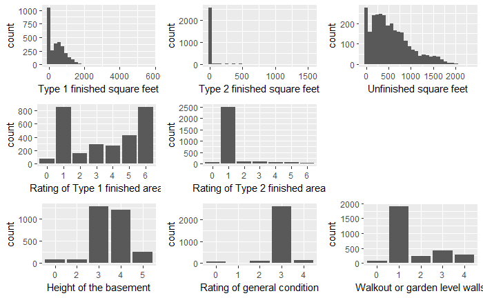

```r
layout <- matrix(c(1,2,3,4,5,9,6,7,8),3,3,byrow=TRUE)
multiplot(b1, b2, b3, b4, b5, b6, b7, b8, layout=layout)
```

So it seemed as if the Total Basement Surface in square feet (TotalBsmtSF) is further broken down into finished areas (2 if more than one type of finish), and unfinished area. I did a check between the correlation of total of those 3 variables, and TotalBsmtSF. The correlation is exactely 1, so that’s a good thing (no errors or small discrepancies)!

Basement Quality is a confusing variable name, as it turns out that it specifically rates the Height of the basement.

7 Feature engineering 7.1 Total number of Bathrooms There are 4 bathroom variables. Individually, these variables are not very important. However, I assume that I if I add them up into one predictor, this predictor is likely to become a strong one.

```r
all$TotBathrooms <- all$FullBath + (all$HalfBath*0.5) + all$BsmtFullBath + (all$BsmtHalfBath*0.5)
```

```r
tb1 <- ggplot(data=all[!is.na(all$SalePrice),], aes(x=as.factor(TotBathrooms), y=SalePrice))+
        geom_point(col='blue') + geom_smooth(method = "lm", se=FALSE, color="black", aes(group=1)) +
        scale_y_continuous(breaks= seq(0, 800000, by=100000), labels = comma)
tb2 <- ggplot(data=all, aes(x=as.factor(TotBathrooms))) +
        geom_histogram(stat='count')
```

```
Ignoring unknown parameters: binwidth, bins, pad
```

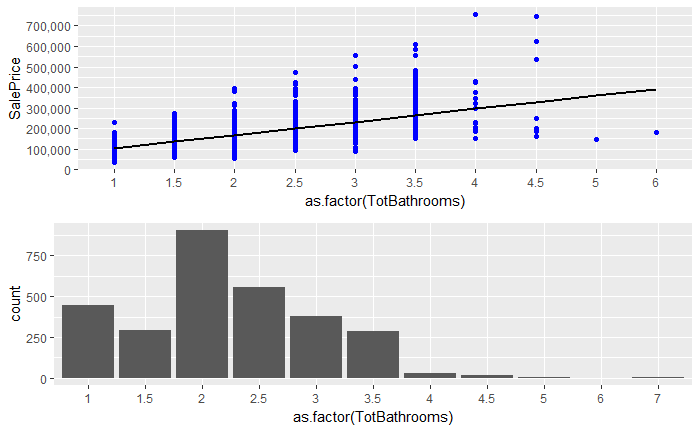

```r
grid.arrange(tb1, tb2)
```

7.2 Adding ‘House Age’, ‘Remodeled (Yes/No)’, and IsNew variables

Altogether, there are 3 variables that are relevant with regards to the Age of a house; YearBlt, YearRemodAdd, and YearSold. YearRemodAdd defaults to YearBuilt if there has been no Remodeling/Addition. I will use YearRemodeled and YearSold to determine the Age. However, as parts of old constructions will always remain and only parts of the house might have been renovated, I will also introduce a Remodeled Yes/No variable. This should be seen as some sort of penalty parameter that indicates that if the Age is based on a remodeling date, it is probably worth less than houses that were built from scratch in that same year.

```r
all$Remod <- ifelse(all$YearBuilt==all$YearRemodAdd, 0, 1) #0=No Remodeling, 1=Remodeling
all$Age <- as.numeric(all$YrSold)-all$YearRemodAdd
```

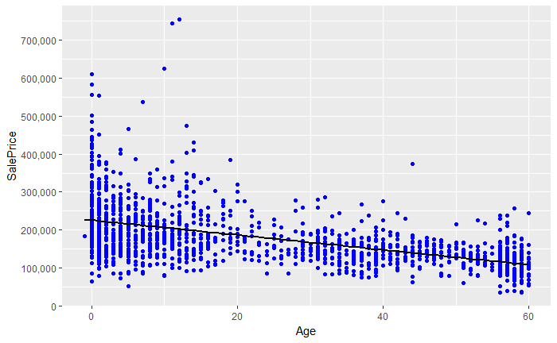

```r
ggplot(data=all[!is.na(all$SalePrice),], aes(x=Age, y=SalePrice))+
        geom_point(col='blue') + geom_smooth(method = "lm", se=FALSE, color="black", aes(group=1)) +
        scale_y_continuous(breaks= seq(0, 800000, by=100000), labels = comma)
```

```r
cor(all$SalePrice[!is.na(all$SalePrice)], all$Age[!is.na(all$SalePrice)])
```

```
[1] -0.5090787
```

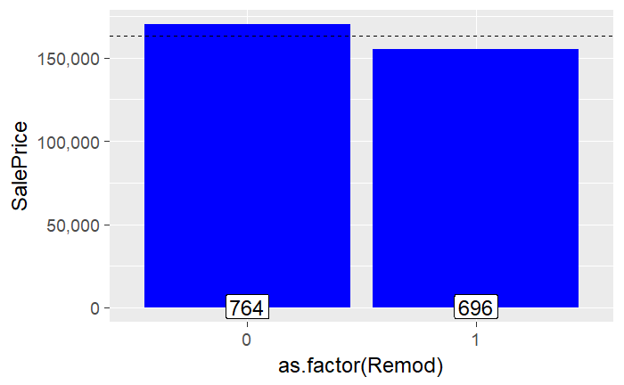

```r
ggplot(all[!is.na(all$SalePrice),], aes(x=as.factor(Remod), y=SalePrice)) +
        geom_bar(stat='summary', fun.y = "median", fill='blue') +
        geom_label(stat = "count", aes(label = ..count.., y = ..count..), size=6) +
        scale_y_continuous(breaks= seq(0, 800000, by=50000), labels = comma) +
        theme_grey(base_size = 18) +
        geom_hline(yintercept=163000, linetype="dashed") #dashed line is median SalePrice
```

Finally, I am creating the IsNew variable below. Altogether, there are 116 new houses in the dataset.

```r
all$IsNew <- ifelse(all$YrSold==all$YearBuilt, 1, 0)
table(all$IsNew)
```

```
   0    1
2803  116
```

These 116 new houses are fairly evenly distributed among train and test set, and as you can see new houses are worth considerably more on average.

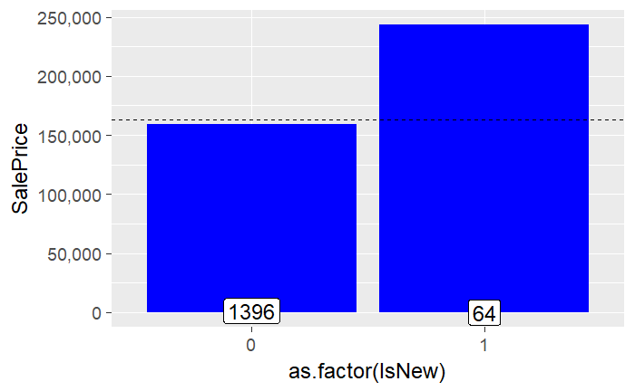

```r
ggplot(all[!is.na(all$SalePrice),], aes(x=as.factor(IsNew), y=SalePrice)) +
        geom_bar(stat='summary', fun.y = "median", fill='blue') +
        geom_label(stat = "count", aes(label = ..count.., y = ..count..), size=6) +
        scale_y_continuous(breaks= seq(0, 800000, by=50000), labels = comma) +
        theme_grey(base_size = 18) +
        geom_hline(yintercept=163000, linetype="dashed") #dashed line is median SalePrice
```

```r
all$YrSold <- as.factor(all$YrSold) #the numeric version is now not needed anymore
```

7.3 Binning Neighborhood

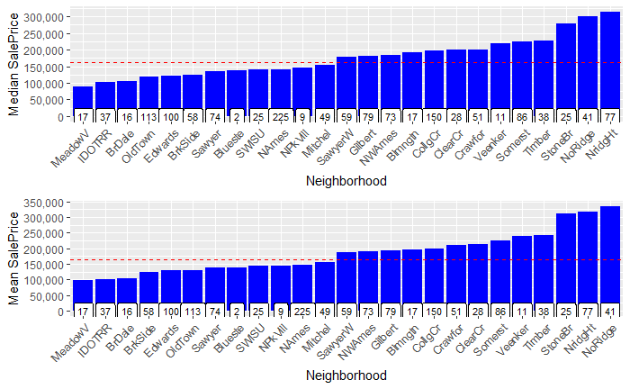

```r
nb1 <- ggplot(all[!is.na(all$SalePrice),], aes(x=reorder(Neighborhood, SalePrice, FUN=median), y=SalePrice)) +
        geom_bar(stat='summary', fun.y = "median", fill='blue') + labs(x='Neighborhood', y='Median SalePrice') +
        theme(axis.text.x = element_text(angle = 45, hjust = 1)) +
        scale_y_continuous(breaks= seq(0, 800000, by=50000), labels = comma) +
        geom_label(stat = "count", aes(label = ..count.., y = ..count..), size=3) +
        geom_hline(yintercept=163000, linetype="dashed", color = "red") #dashed line is median SalePrice
nb2 <- ggplot(all[!is.na(all$SalePrice),], aes(x=reorder(Neighborhood, SalePrice, FUN=mean), y=SalePrice)) +
        geom_bar(stat='summary', fun.y = "mean", fill='blue') + labs(x='Neighborhood', y="Mean SalePrice") +
        theme(axis.text.x = element_text(angle = 45, hjust = 1)) +
        scale_y_continuous(breaks= seq(0, 800000, by=50000), labels = comma) +
        geom_label(stat = "count", aes(label = ..count.., y = ..count..), size=3) +
        geom_hline(yintercept=163000, linetype="dashed", color = "red") #dashed line is median SalePrice
grid.arrange(nb1, nb2)
```

Both the median and mean Saleprices agree on 3 neighborhoods with substantially higher saleprices. The separation of the 3 relatively poor neighborhoods is less clear, but at least both graphs agree on the same 3 poor neighborhoods. Since I do not want to ‘overbin’, I am only creating categories for those ‘extremes’.

```r
all$NeighRich[all$Neighborhood %in% c('StoneBr', 'NridgHt', 'NoRidge')] <- 2
all$NeighRich[!all$Neighborhood %in% c('MeadowV', 'IDOTRR', 'BrDale', 'StoneBr', 'NridgHt', 'NoRidge')] <- 1
all$NeighRich[all$Neighborhood %in% c('MeadowV', 'IDOTRR', 'BrDale')] <- 0
table(all$NeighRich)
```

```
   0    1    2
 160 2471  288
```

7.4 Total Square Feet

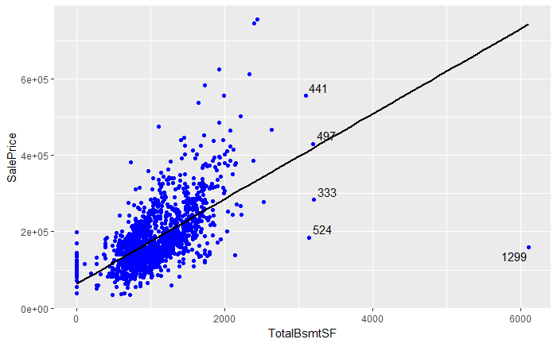

```r
#Total basement square feet
outlier <- 3000
ggplot(data = all[!is.na(all$SalePrice),], aes(x=TotalBsmtSF , y=SalePrice)) +
      geom_point(col="blue") +
      geom_smooth(method = "lm", se=FALSE, color="black", aes(group=1)) +
      #scale_y_continuous(breaks = seq(0, 800000, by=100000), labels = comma) +
      geom_text_repel(aes(label=ifelse(all$TotalBsmtSF [!is.na(all$SalePrice)]>outlier, rownames(all), "")))
```

```r
cor(all$SalePrice, all$TotalBsmtSF, use= "pairwise.complete.obs")
```

```
[1] 0.6135806
```

```r
cor(all$SalePrice[-c(333, 441, 497, 1299)], all$TotalBsmtSF[-c(333, 441, 497, 1299)], use= "pairwise.complete.obs")
```

```
[1] 0.6385938
```

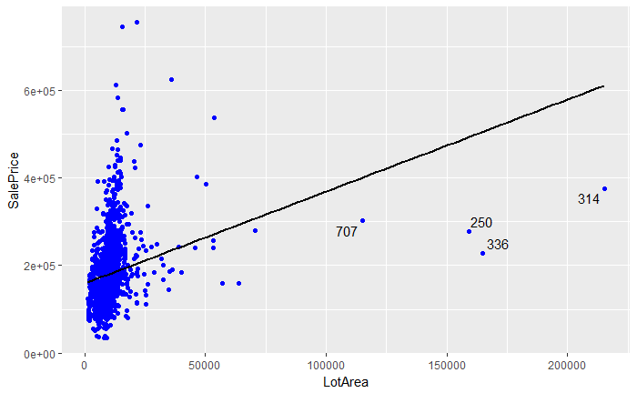

```r
#Total basement square feet
outlier <- 100000
ggplot(data = all[!is.na(all$SalePrice),], aes(x=LotArea  , y=SalePrice)) +
      geom_point(col="blue") +
      geom_smooth(method = "lm", se=FALSE, color="black", aes(group=1)) +
      #scale_y_continuous(breaks = seq(0, 800000, by=100000), labels = comma) +
      geom_text_repel(aes(label=ifelse(all$LotArea  [!is.na(all$SalePrice)]>outlier, rownames(all), "")))
```

```r
cor(all$SalePrice, all$LotArea , use= "pairwise.complete.obs")
```

```
[1] 0.2638434
```

```r
cor(all$SalePrice[-c(250, 314, 336, 707)], all$LotArea [-c(250, 314, 336, 707)], use= "pairwise.complete.obs")
```

```
[1] 0.3544944
```

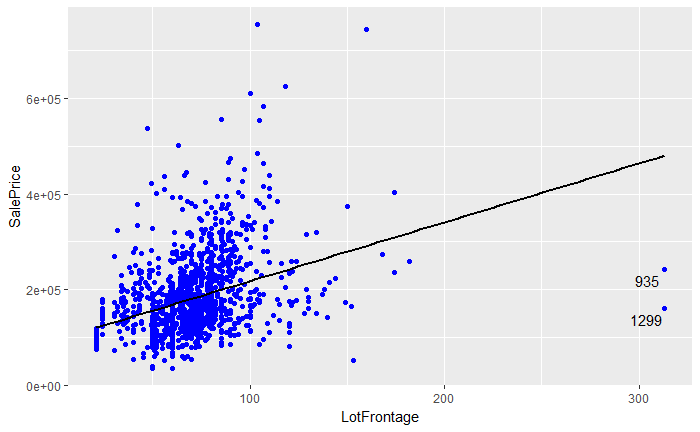

```r
#lot frontage
outlier <- 200
ggplot(data = all[!is.na(all$SalePrice),], aes(x=LotFrontage   , y=SalePrice)) +
      geom_point(col="blue") +
      geom_smooth(method = "lm", se=FALSE, color="black", aes(group=1)) +
      #scale_y_continuous(breaks = seq(0, 800000, by=100000), labels = comma) +
      geom_text_repel(aes(label=ifelse(all$LotFrontage   [!is.na(all$SalePrice)]>outlier, rownames(all), "")))
```

```r
cor(all$SalePrice, all$LotFrontage  , use= "pairwise.complete.obs")
```

```
[1] 0.3477279
```

```r
cor(all$SalePrice[-c(935, 1299)], all$LotFrontage  [-c(935, 1299)], use= "pairwise.complete.obs")
```

```
[1] 0.3755848
```

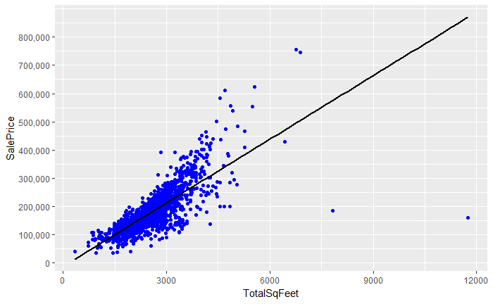

```r
all$TotalSqFeet <- all$GrLivArea + all$TotalBsmtSF
ggplot(data=all[!is.na(all$SalePrice),], aes(x=TotalSqFeet, y=SalePrice))+
        geom_point(col='blue') + geom_smooth(method = "lm", se=FALSE, color="black", aes(group=1)) +
        scale_y_continuous(breaks= seq(0, 800000, by=100000), labels = comma) +
        geom_text_repel(aes(label = ifelse(all$GrLivArea[!is.na(all$SalePrice)]>4500, rownames(all), '')))
```

```r
cor(all$SalePrice, all$TotalSqFeet, use= "pairwise.complete.obs")
```

```
[1] 0.7789588
```

The two potential outliers seem to ‘outlie’ even more than before. By taking out these two outliers, the correlation increases by 5%.

```r
cor(all$SalePrice[-c(524, 1299)], all$TotalSqFeet[-c(524, 1299)], use= "pairwise.complete.obs")
```

```
[1] 0.829042
```

[figure not shown]

```r
#summary (all)

# MiscVal             MoSold     YrSold       SaleType    SaleCondition    SalePrice      TotBathrooms       Remod             Age
# durSold        has2ndFloor        hasPool            season         IsNew           NeighRich      TotalSqFeet     TotalPorchSF
# ggplot(data=all[!is.na(all$SalePrice),], aes(x=NeighRich, y=SalePrice)) +
#       geom_point(col='blue') + geom_smooth(method = "lm", se=FALSE, color="black", aes(group=1)) +
#       scale_y_continuous(breaks= seq(0, 800000, by=100000), labels = comma) +
#         theme(axis.text.x = element_text(angle = 45, hjust = 1)) #+
        #geom_text_repel(aes(label = ifelse(all$EnclosedPorch[!is.na(all$SalePrice)]>400, rownames(all), '')))
ggplot(data=all[!is.na(all$SalePrice),], aes(x=TotalPorchSF, y=SalePrice))+
      geom_point(col='blue') + geom_smooth(method = "lm", se=FALSE, color="black", aes(group=1)) +
      scale_y_continuous(breaks= seq(0, 800000, by=100000), labels = comma) +
        theme(axis.text.x = element_text(angle = 45, hjust = 1)) +
        geom_text_repel(aes(label = ifelse(all$TotalPorchSF[!is.na(all$SalePrice)]>1000, rownames(all), '')))
```

7.5 Consolidating Porch variables Below, I listed the variables that seem related regarding porches.

WoodDeckSF: Wood deck area in square feet

OpenPorchSF: Open porch area in square feet

EnclosedPorch: Enclosed porch area in square feet

3SsnPorch: Three season porch area in square feet

ScreenPorch: Screen porch area in square feet

As far as I know, porches are sheltered areas outside of the house, and a wooden deck is unsheltered. Therefore, I am leaving WoodDeckSF alone, and are only consolidating the 4 porch variables.

```r
all$TotalPorchSF <- all$OpenPorchSF + all$EnclosedPorch + all$X3SsnPorch + all$ScreenPorch
cor(all$SalePrice, all$TotalPorchSF, use= "pairwise.complete.obs")
```

```
[1] 0.1957389
```

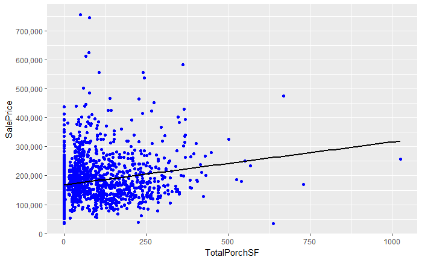

```r
ggplot(data=all[!is.na(all$SalePrice),], aes(x=TotalPorchSF, y=SalePrice))+
        geom_point(col='blue') + geom_smooth(method = "lm", se=FALSE, color="black", aes(group=1)) +
        scale_y_continuous(breaks= seq(0, 800000, by=100000), labels = comma)
```

8 Preparing data for modeling

8.1 Dropping highly correlated variables First of all, I am dropping a variable if two variables are highly correlated. To find these correlated pairs, I have used the correlations matrix again (see section 6.1). For instance: GarageCars and GarageArea have a correlation of 0.89. Of those two, I am dropping the variable with the lowest correlation with SalePrice (which is GarageArea with a SalePrice correlation of 0.62. GarageCars has a SalePrice correlation of 0.64).

```r
dropVars <- c('YearRemodAdd', 'GarageYrBlt', 'GarageArea', 'GarageCond', 'TotalBsmtSF', 'TotalRmsAbvGrd', 'BsmtFinSF1')
all <- all[,!(names(all) %in% dropVars)]
```

8.2 Removing outliers

```r
all <- all[-c(524, 1299),]
```

8.3 PreProcessing predictor variables Before modeling I need to center and scale the ‘true numeric’ predictors (so not variables that have been label encoded), and create dummy variables for the categorical predictors. Below, I am splitting the dataframe into one with all (true) numeric variables, and another dataframe holding the (ordinal) factors.

```r
numericVarNames <- numericVarNames[!(numericVarNames %in% c('MSSubClass', 'MoSold', 'YrSold', 'SalePrice', 'OverallQual', 'OverallCond'))] #numericVarNames was created before having done anything
numericVarNames <- append(numericVarNames, c('Age', 'TotalPorchSF', 'TotBathrooms', 'TotalSqFeet'))
DFnumeric <- all[, names(all) %in% numericVarNames]
DFfactors <- all[, !(names(all) %in% numericVarNames)]
DFfactors <- DFfactors[, names(DFfactors) != 'SalePrice']
cat('There are', length(DFnumeric), 'numeric variables, and', length(DFfactors), 'factor variables')
```

```
There are 30 numeric variables, and 49 factor variables
```

8.3.1 Skewness and normalizing of the numeric predictors Skewness Skewness is a measure of the symmetry in a distribution. A symmetrical dataset will have a skewness equal to 0. So, a normal distribution will have a skewness of 0. Skewness essentially measures the relative size of the two tails. As a rule of thumb, skewness should be between -1 and 1. In this range, data are considered fairly symmetrical. In order to fix the skewness, I am taking the log for all numeric predictors with an absolute skew greater than 0.8 (actually: log+1, to avoid division by zero issues).

```r
for(i in 1:ncol(DFnumeric)){
        if (abs(skew(DFnumeric[,i]))>0.8){
                DFnumeric[,i] <- log(DFnumeric[,i] +1)
        }
}
```

Normalizing the data

```r
PreNum <- preProcess(DFnumeric, method=c("center", "scale"))
print(PreNum)
```

```
Created from 2917 samples and 30 variables

Pre-processing:
  - centered (30)
  - ignored (0)
  - scaled (30)
```

```r
DFnorm <- predict(PreNum, DFnumeric)
dim(DFnorm)
```

```
[1] 2917   30
```

8.3.2 One hot encoding the categorical variables

```r
DFdummies <- as.data.frame(model.matrix(~.-1, DFfactors))
dim(DFdummies)
```

```
[1] 2917  201
```

In previous versions, I worked with Caret’s Near Zero Variance function. Although this works, it also is a quick fix and too much information got lost. For instance, by using the defaults, all Neighborhoods with less than 146 houses are omitted as (one-hot encoded) variables (frequency ratio higher than 95/5). Therefore, I have taken amore carefull manual approach in this version.

```r
#check if some values are absent in the test set
ZerocolTest <- which(colSums(DFdummies[(nrow(all[!is.na(all$SalePrice),])+1):nrow(all),])==0)
colnames(DFdummies[ZerocolTest])
```

```
 [1] "Condition2RRAe"     "Condition2RRAn"     "Condition2RRNn"     "HouseStyle2.5Fin"   "RoofMatlMembran"    "RoofMatlMetal"      "RoofMatlRoll"
 [8] "Exterior1stImStucc" "Exterior1stStone"   "Exterior2ndOther"   "HeatingOthW"        "ElectricalMix"      "MiscFeatureTenC"
```

```r
DFdummies <- DFdummies[,-ZerocolTest] #removing predictors
```

```r
#check if some values are absent in the train set
ZerocolTrain <- which(colSums(DFdummies[1:nrow(all[!is.na(all$SalePrice),]),])==0)
colnames(DFdummies[ZerocolTrain])
```

```
[1] "MSSubClass1,5 story PUD all"
```

```r
DFdummies <- DFdummies[,-ZerocolTrain] #removing predictor
```

Also taking out variables with less than 10 ‘ones’ in the train set.

```r
fewOnes <- which(colSums(DFdummies[1:nrow(all[!is.na(all$SalePrice),]),])<10)
colnames(DFdummies[fewOnes])
```

```
 [1] "MSSubClass1 story unf attic" "LotConfigFR3"                "NeighborhoodBlueste"         "NeighborhoodNPkVill"         "Condition1PosA"
 [6] "Condition1RRNe"              "Condition1RRNn"              "Condition2Feedr"             "Condition2PosA"              "Condition2PosN"
[11] "RoofStyleMansard"            "RoofStyleShed"               "RoofMatlWdShake"             "RoofMatlWdShngl"             "Exterior1stAsphShn"
[16] "Exterior1stBrkComm"          "Exterior1stCBlock"           "Exterior2ndAsphShn"          "Exterior2ndBrk Cmn"          "Exterior2ndCBlock"
[21] "Exterior2ndStone"            "FoundationStone"             "FoundationWood"              "HeatingGrav"                 "HeatingWall"
[26] "ElectricalFuseP"             "GarageTypeCarPort"           "MiscFeatureOthr"             "SaleTypeCon"                 "SaleTypeConLD"
[31] "SaleTypeConLI"               "SaleTypeConLw"               "SaleTypeCWD"                 "SaleTypeOth"                 "SaleConditionAdjLand"
```

```r
DFdummies <- DFdummies[,-fewOnes] #removing predictors
dim(DFdummies)
```

```
[1] 2917  152
```

8.4 Dealing with skewness of response variable

```r
skew(all$SalePrice)
```

```
[1] 1.877427
```

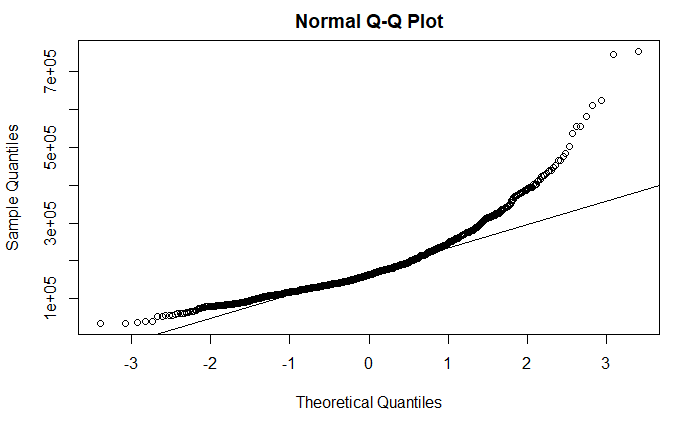

```r
qqnorm(all$SalePrice)
qqline(all$SalePrice)
```

The skew of 1.87 indicates a right skew that is too high, and the Q-Q plot shows that sale prices are also not normally distributed. To fix this I am taking the log of SalePrice.

```r
all$SalePrice <- log(all$SalePrice) #default is the natural logarithm, "+1" is not necessary as there are no 0's
skew(all$SalePrice)
```

```
[1] 0.1213182
```

As you can see,the skew is now quite low and the Q-Q plot is also looking much better.

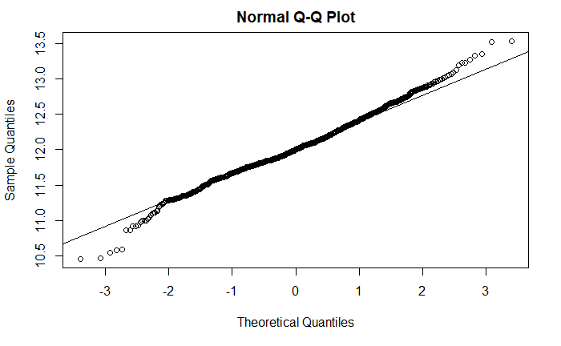

```r
qqnorm(all$SalePrice)
qqline(all$SalePrice)
```

8.5 Composing train and test sets

Altogether, I have removed 49 one-hot encoded predictors with little or no variance. Although this may seem a significant number, it is actually much less than the number of predictors that were taken out by using caret’snear zero variance function (using its default thresholds).

```r
combined <- cbind(DFnorm, DFdummies) #combining all (now numeric) predictors into one dataframe
```

```r
train1 <- combined[!is.na(all$SalePrice),]
test1 <- combined[is.na(all$SalePrice),]
dim(train)
```

```
[1] 1460   80
```

```r
dim(train1)
```

```
[1] 1458  182
```

```r
dim(test)
```

```
[1] 1459   80
```

```r
dim(test1)
```

```
[1] 1459  182
```

```r
train1[c(1:20), ]
```

|  | LotFrontage | LotArea | YearBuilt | MasVnrArea | BsmtFinSF2 | BsmtUnfSF | X1stFlrSF | X2ndFlrSF | LowQualFinSF | GrLivArea | BsmtFullBath | BsmtHalfBath | FullBath | HalfBath | BedroomAbvGr | KitchenAbvGr | TotRmsAbvGrd | Fireplaces | GarageCars | WoodDeckSF | OpenPorchSF | EnclosedPorch | X3SsnPorch | ScreenPorch | PoolArea | MiscVal | TotBathrooms | Age | TotalSqFeet | … |
| --- | --- | --- | --- | --- | --- | --- | --- | --- | --- | --- | --- | --- | --- | --- | --- | --- | --- | --- | --- | --- | --- | --- | --- | --- | --- | --- | --- | --- | --- | --- |
| 1 | -0.049712282 | -0.1017437 | 1.04705129 | 1.2245218 | -0.3626439 | -0.32481982 | -0.77834637 | 1.1978525 | -0.116953 | 0.5701193 | 1.0900703 | -0.2515929 | 0.7831023 | 1.2334526 | 0.1699579 | -0.2005503 | 0.9921086 | -0.9246045 | 0.3076852 | -0.9442794 | 0.8344301 | -0.4276454 | -0.112794 | -0.3092074 | -0.06407061 | -0.1893637 | 1.5902303 | -0.8877439 | 0.17377295 | … |
| 2 | 0.575174507 | 0.1494097 | 0.15557943 | -0.7926862 | -0.3626439 | 0.01489152 | 0.42956794 | -0.8627768 | -0.116953 | -0.3694659 | -0.8185342 | 3.8867695 | 0.7831023 | -0.7554812 | 0.1699579 | -0.2005503 | -0.2864338 | 0.6263278 | 0.3076852 | 1.2548766 | -1.0824844 | -0.4276454 | -0.112794 | -0.3092074 | -0.06407061 | -0.1893637 | 0.3509298 | 0.3568864 | 0.12069579 | … |
| 3 | 0.085922860 | 0.4616028 | 0.98101634 | 1.1521856 | -0.3626439 | 0.24103628 | -0.55401700 | 1.2021066 | -0.116953 | 0.7046259 | 1.0900703 | -0.2515929 | 0.7831023 | 1.2334526 | 0.1699579 | -0.2005503 | -0.2864338 | 0.6263278 | 0.3076852 | -0.9442794 | 0.6644660 | -0.4276454 | -0.112794 | -0.3092074 | -0.06407061 | -0.1893637 | 1.5902303 | -0.8398735 | 0.34462760 | … |
| 4 | -0.290095451 | 0.1391311 | -1.85848661 | -0.7926862 | -0.3626439 | 0.35766233 | -0.41835680 | 1.1606945 | -0.116953 | 0.5827554 | 1.0900703 | -0.2515929 | -1.0269686 | -0.7554812 | 0.1699579 | -0.2005503 | 0.3528374 | 0.6263278 | 1.6198458 | -0.9442794 | 0.5819391 | 2.7372726 | -0.112794 | -0.3092074 | -0.06407061 | -0.1893637 | -0.2687205 | 0.5962383 | 0.05504515 | … |
| 5 | 0.722253015 | 0.9282918 | 0.94799886 | 1.4450517 | -0.3626439 | 0.30579981 | 0.12677821 | 1.2617205 | -0.116953 | 1.3467147 | 1.0900703 | -0.2515929 | 0.7831023 | 1.2334526 | 1.3850734 | -0.2005503 | 1.6313799 | 0.6263278 | 1.6198458 | 1.0859971 | 0.9809770 | -0.4276454 | -0.112794 | -0.3092074 | -0.06407061 | -0.1893637 | 1.5902303 | -0.7441327 | 1.02455292 | … |
| 6 | 0.757941004 | 0.9081739 | 0.71687653 | -0.7926862 | -0.3626439 | -0.77560059 | -1.00442348 | 1.0724823 | -0.116953 | -0.1336372 | 1.0900703 | -0.2515929 | -1.0269686 | 1.2334526 | -2.2602731 | -0.2005503 | -0.9257051 | -0.9246045 | 0.3076852 | 0.4883678 | 0.5124867 | -0.4276454 | 9.714486 | -0.3092074 | -0.06407061 | 5.0922943 | 0.3509298 | -0.4569104 | -0.38313799 | … |
| 7 | 0.380759190 | 0.2462272 | 1.08006877 | 1.2046311 | -0.3626439 | 0.07348562 | 1.34589906 | -0.8627768 | -0.116953 | 0.5410416 | 1.0900703 | -0.2515929 | 0.7831023 | -0.7554812 | 0.1699579 | -0.2005503 | 0.3528374 | 0.6263278 | 0.3076852 | 1.1949770 | 0.8034542 | -0.4276454 | -0.112794 | -0.3092074 | -0.06407061 | -0.1893637 | 0.9705800 | -1.0313551 | 1.05995678 | … |
| 8 | 0.575174507 | 0.3035529 | 0.05652701 | 1.3014932 | 1.4981014 | -0.13089118 | 0.02174634 | 1.2407446 | -0.116953 | 1.1908529 | 1.0900703 | -0.2515929 | 0.7831023 | 1.2334526 | 0.1699579 | -0.2005503 | 0.3528374 | 2.1772601 | 0.3076852 | 1.1635949 | 1.3898739 | 2.6381129 | -0.112794 | -0.3092074 | -0.06407061 | 4.5347311 | 1.5902303 | 0.5962383 | 0.88092089 | … |
| 9 | -0.777173042 | -0.7367203 | -1.33020699 | -0.7926862 | -0.3626439 | 0.66046498 | -0.22686229 | 1.1590774 | -0.116953 | 0.6837728 | -0.8185342 | -0.2515929 | 0.7831023 | -0.7554812 | -1.0451576 | 4.3952775 | 0.9921086 | 2.1772601 | 0.3076852 | 0.7959508 | -1.0824844 | 2.5783937 | -0.112794 | -0.3092074 | -0.06407061 | -0.1893637 | -0.2687205 | 1.6493870 | 0.36831128 | … |
| 10 | -0.836423220 | -0.3575991 | -1.06606718 | -0.7926862 | -0.3626439 | -0.36146443 | -0.06375021 | -0.8627768 | -0.116953 | -0.8596488 | 1.0900703 | -0.2515929 | -1.0269686 | -0.7554812 | -1.0451576 | 4.3952775 | -0.9257051 | 2.1772601 | -1.0044753 | -0.9442794 | -0.3349548 | -0.4276454 | -0.112794 | -0.3092074 | -0.06407061 | -0.1893637 | -0.2687205 | 1.6493870 | -0.52013466 | … |

[output cut: 10 more lines]

9.1 Lasso regression model I have also tried Ridge and Elastic Net models, but since lasso gives the best results of those 3 models I am only keeping the lasso model in the document.

Below, I am using caret cross validation to find the best value for lambda, which is the only hyperparameter that needs to be tuned for the lasso model.

```r
set.seed(27042018)
my_control <-trainControl(method="cv", number=5)
lassoGrid <- expand.grid(alpha = 1, lambda = seq(0.001,0.1,by = 0.0005))
lasso_mod <- train(x=train1, y=all$SalePrice[!is.na(all$SalePrice)], method='glmnet', trControl= my_control, tuneGrid=lassoGrid)
lasso_mod$bestTune
```

|  | alpha | lambda |
| --- | --- | --- |
| 4 | 1 | 0.0025 |

```r
min(lasso_mod$results$RMSE)
```

```
[1] 0.1121579
```

The documentation of the caret `varImp’ function says: for glmboost and glmnet the absolute value of the coefficients corresponding to the tuned model are used.

Although this means that a real ranking of the most important variables is not stored, it gives me the opportunity to find out how many of the variables are not used in the model (and hence have coefficient 0).

```r
lassoVarImp <- varImp(lasso_mod,scale=F)
lassoImportance <- lassoVarImp$importance
varsSelected <- length(which(lassoImportance$Overall!=0))
varsNotSelected <- length(which(lassoImportance$Overall==0))
cat('Lasso uses', varsSelected, 'variables in its model, and did not select', varsNotSelected, 'variables.')
```

```
Lasso uses 100 variables in its model, and did not select 82 variables.
```

So lasso did what it is supposed to do: it seems to have dealt with multicolinearity well by not using about 45% of the available variables in the model.

```r
LassoPred <- predict(lasso_mod, test1)
predictions_lasso <- exp(LassoPred) #need to reverse the log to the real values
head(predictions_lasso)
```

```
    1461     1462     1463     1464     1465     1466
114351.8 162204.8 179455.3 197564.7 205952.8 169839.8
```

9.2 XGBoost model Initially, I just worked with the XGBoost package directly. The main reason for this was that the package uses its own efficient datastructure (xgb.DMatrix). The package also provides a cross validation function. However, this CV function only determines the optimal number of rounds, and does not support a full grid search of hyperparameters.

Although caret does not seem to use the (fast) datastructure of the xgb package, I eventually decided to do hyperparameter tuning with it anyway, as it at least supports a full grid search. As far as I understand it, the main parameters to tune to avoid overfitting are max_depth, and min_child_weight (see XGBoost documentation). Below I am setting up a grid that tunes both these parameters, and also the eta (learning rate).

```r
xgb_grid = expand.grid(
nrounds = 1000,
eta = c(0.1, 0.05, 0.01),
max_depth = c(2, 3, 4, 5, 6),
gamma = 0,
colsample_bytree=1,
min_child_weight=c(1, 2, 3, 4 ,5),
subsample=1
)
```

The next step is to let caret find the best hyperparameter values (using 5 fold cross validation).

```r
xgb_caret <- train(x=train1, y=all$SalePrice[!is.na(all$SalePrice)], method='xgbTree', trControl= my_control, tuneGrid=xgb_grid)
xgb_caret$bestTune
```

|  | nrounds | max_depth | eta | gamma | colsample_bytree | min_child_weight | subsample |
| --- | --- | --- | --- | --- | --- | --- | --- |
| 34 | 1000 | 3 | 0.05 | 0 | 1 | 4 | 1 |

According to caret, the ‘bestTune’ parameters are:

Max_depth=3 eta=0.05 Min_child_weight=4

In the remainder of this section, I will continue to work with the xgboost package directly. Below, I am starting with the preparation of the data in the recommended format.

```r
label_train <- all$SalePrice[!is.na(all$SalePrice)]
# put our testing & training data into two seperates Dmatrixs objects
dtrain <- xgb.DMatrix(data = as.matrix(train1), label= label_train)
dtest <- xgb.DMatrix(data = as.matrix(test1))
```

In addition, I am taking over the best tuned values from the caret cross validation.

```r
default_param<-list(
        objective = "reg:linear",
        booster = "gbtree",
        eta=0.05, #default = 0.3
        gamma=0,
        max_depth=3, #default=6
        min_child_weight=4, #default=1
        subsample=1,
        colsample_bytree=1
)
```

The next step is to do cross validation to determine the best number of rounds (for the given set of parameters).

```r
xgbcv <- xgb.cv( params = default_param, data = dtrain, nrounds = 500, nfold = 5, showsd = T, stratified = T, print_every_n = 40, early_stopping_rounds = 10, maximize = F)
```

[output not shown]

```r
#train the model using the best iteration found by cross validation
xgb_mod <- xgb.train(data = dtrain, params=default_param, nrounds = 454)
```

```r
XGBpred <- predict(xgb_mod, dtest)
predictions_XGB <- exp(XGBpred) #need to reverse the log to the real values
head(predictions_XGB)
```

```
[1] 116386.8 162307.3 186494.0 187440.4 187258.3 166241.4
```

[figure not shown]

```r
#view variable importance plot
library(Ckmeans.1d.dp) #required for ggplot clustering
mat <- xgb.importance (feature_names = colnames(train1),model = xgb_mod)
xgb.ggplot.importance(importance_matrix = mat[1:20], rel_to_first = TRUE)
```

```r
sub_avg <- data.frame(Id = test_labels, SalePrice = (predictions_XGB+2*predictions_lasso)/3)
head(sub_avg)
```

|  | Id | SalePrice |
| --- | --- | --- |
| 1461 | 1461 | 115030.1 |
| 1462 | 1462 | 162238.9 |
| 1463 | 1463 | 181801.5 |
| 1464 | 1464 | 194189.9 |
| 1465 | 1465 | 199721.3 |
| 1466 | 1466 | 168640.3 |

```r
write.csv(sub_avg, file = 'average.csv', row.names = F)
```

10. Test

```r
drop_features = c()#'OpenPorchSF', 'EnclosedPorch', '3SsnPorch', 'ScreenPorch')#, 'RoofMatl', 'MasVnrArea',
               #  'BsmtFinSF1', 'BsmtFinSF2', 'BsmtUnfSF',
               #  'Heating', 'LowQualFinSF',
               # 'BsmtFullBath', 'BsmtHalfBath',
               # 'Functional',
               # 'GarageYrBlt', 'GarageArea', 'GarageCond',
               # 'WoodDeckSF',
               # 'OpenPorchSF', 'EnclosedPorch', '3SsnPorch', 'ScreenPorch',
               # 'PoolArea', 'PoolQC',
               # "Alley")
               #'Fence', 'MiscFeature', 'MiscVal',
               #, "ExterCond", "BsmtFinSF2", "Heating", "Electrical")
               #"BsmtHalfBath", "PavedDrive", "Fence", "MiscFeature", "MoSold",
               #"BsmtFinType2", "LandContour", "EnclosedPorch",
               #"SaleType", "Functional", "LotConfig",
               #"ScreenPorch", "YrSold", "LandSlope")
combined2 <- combined[,!(names(all) %in% drop_features)]
train2 <- combined2[!is.na(all$SalePrice),]
test2 <- combined2[is.na(all$SalePrice),]
dim(train)
```

```
[1] 1460   80
```

```r
dim(train1)
```

```
[1] 1458  182
```

```r
dim(train2)
```

```
[1] 1458  182
```

```r
dim(test)
```

```
[1] 1459   80
```

```r
dim(test1)
```

```
[1] 1459  182
```

```r
dim(test2)
```

```
[1] 1459  182
```

```r
xgb_grid = expand.grid(
nrounds = 700,
eta = c(0.1, 0.05, 0.01),
max_depth = c(2, 3, 5),
gamma = 0,
colsample_bytree=1,
min_child_weight=c(1, 2, 5),
subsample=1
)
#xgb_caret2 <- train(x=train2, y=all$SalePrice[!is.na(all$SalePrice)], method='xgbTree', trControl= my_control, tuneGrid=xgb_grid)
xgb_caret$bestTune
```

|  | nrounds | max_depth | eta | gamma | colsample_bytree | min_child_weight | subsample |
| --- | --- | --- | --- | --- | --- | --- | --- |
| 34 | 1000 | 3 | 0.05 | 0 | 1 | 4 | 1 |

```r
default_param<-list(
        objective = "reg:linear",
        booster = "gbtree",
        eta=0.05, #default = 0.3
        gamma=0.1,
        max_depth=4, #default=6
        min_child_weight=1, #default=1
        subsample=1,
        colsample_bytree=1
)
dtrain <- xgb.DMatrix(data = as.matrix(train1), label= label_train)
dtest <- xgb.DMatrix(data = as.matrix(test1))
xgbcv <- xgb.cv( params = default_param, data = dtrain, nrounds = 500, nfold = 5, showsd = T, stratified = T, print_every_n = 40, early_stopping_rounds = 10, maximize = F)
```

[output not shown]

```r
sub_lasso <- data.frame(Id = test_labels, SalePrice = predictions_lasso)
write.csv(sub_lasso, file = 'lasso.csv', row.names = F)

sub_xgb <- data.frame(Id = test_labels, SalePrice = predictions_XGB)
write.csv(sub_xgb, file = 'xgb', row.names = F)
```